# 자연언어처리 15주차_딥러닝을 사용한 자연언어처리 #3: 딥러닝 임베딩, 트랜스포머 모델 미세조정 그리고 LIME

고려대학교 일반대학원 심리학과

2025년 12월 8일 월요일 4-5교시

| 함수 | 출처 패키지/모듈 | 역할 | 주요 논항 및 예시 |
| --- | --- | --- | --- |
| `import()` | reticulate(R) | 파이썬 라이브러리를 R 환경으로 불러옴 | `import("transformers")` |
| `AutoTokenizer$from_pretrained()` | transformers(Python) | Hugging Face에서 사전학습된 토크나이저를 로드함 | `AutoTokenizer$from_pretrained("klue/roberta-base")` |
| `AutoModel$from_pretrained()` | transformers(Python) | Hugging Face에서 사전학습된 모델(가중치 포함)을 로드함 | `AutoModel$from_pretrained("klue/roberta-base")` |
| `model$to()` | PyTorch(Python) | 모델을 연산장치(CPU 또는 GPU)로 이동시킴 | `model$to("cuda")` |
| `model$eval()` | PyTorch(Python) | 모델을 평가(inference) 모드로 전환함(dropout 비활성화 등) | `model$eval()` |
| `tokenizer()` | transformers(Python) | 텍스트를 모델 입력 가능한 숫자(토큰 ID)로 변환함 | `tokenizer(text, padding=TRUE, truncation=TRUE, return_tensors="pt")` |
| `model()` | transformers(Python) | 입력 데이터를 모델에 통과시켜 출력(은닉상태 등)을 얻음 | `model(input_ids=..., attention_mask=...)` |
| `get_peft_model()` | peft(Python) | 기존 모델에 PEFT(LoRA) 설정을 적용하여 래핑함 | `peft$get_peft_model(model, peft_config)` |
| `LoraConfig()` | peft(Python) | LoRA 미세조정을 위한 하이퍼파라미터를 설정함 | `peft$LoraConfig(task_type="SEQ_CLS", r=8, lora_alpha=16)` |
| `Trainer()` | transformers(Python) | 모델 학습을 관리하고 실행하는 트레이너 객체를 생성함 | `Trainer(model=..., args=..., train_dataset=...)` |
| `trainer$train()` | transformers(Python) | 설정된 파라미터로 모델 학습을 시작함 | `trainer$train()` |
| `trainer$evaluate()` | transformers(Python) | 테스트 데이터셋으로 학습된 모델의 성능을 평가함 | `trainer$evaluate()` |

# 1. 수업개요

## (1) RNN vs. 트랜스포머

- RNN 계열 모델
  - 지난 시간에는 RNN과 LSTM을 이용해 순차적인 텍스트 데이터를 처리하고 문장을 생성하는 방법에 대해 배웠음.
  - 하지만 RNN 계열의 모델은 긴 시퀀스를 처리할 때 정보가 손실되는 ’장기 의존성 문제’와 순차적 처리로 인한 느린 학습 속도라는 단점이 있었음.
- transformer 모델
  - 이번 시간에는 이러한 단점을 극복하고 현재 자연언어처리 분야의 표준이 된 **트랜스포머(transformer)** 아키텍처와 이를 활용해 텍스트를 고차원 벡터로 변환하는 **맥락적(contextualized) 임베딩**에 대해 배울 예정임.
  - 또한 저용량 VRAM(video random access memory: GPU에 내장된 전용 고속 메모리) 환경에서도 거대한 트렌스포머 모델을 효과적으로 학습시킬 수 있는 최신 기법인 **LoRA(low-rank adaptation)**를 활용한 미세조정(fine-tuning) 실습까지 진행할 것임.

## (2) 학습목표

1. 기존 임베딩(word2vec)과 트랜스포머 기반 임베딩(BERT 등)의 핵심적인 차이(맥락반영)를 이해함.
2. [Hugging Face](https://huggingface.co/) 플랫폼의 역할과 중요성을 이해하고, 원하는 한국어 모델을 검색할 수 있음.
3. R 환경에서 **reticulate** 패키지를 통해 Hugging Face의 사전학습 모델을 로드하고 텍스트를 임베딩 벡터로 변환할 수 있음.
4. 대량의 텍스트 데이터에 대한 임베딩 추출을 효율적으로 수행하기 위해 병렬처리(parallel processing) 기법을 적용할 수 있음.
5. 생성된 텍스트 임베딩을 활용하여 지도학습(분류) 및 비지도학습(시각화, 군집화) 작업을 수행할 수 있음.
6. 트랜스포머 미세조정의 개념과 필요성을 이해하고, PEFT(LoRA) 기법을 활용해 저용량 VRAM 환경에서 모델을 미세조정할 수 있음.
7. LIME 기법을 활용해 기계학습/딥 러닝 모델이 내린 추론의 근거를 확인하고 해석할 수 있음.

# 2. 이론적 배경: 트랜스포머와 맥락적 임베딩

## (1) 왜 트랜스포머인가?

- “Attention Is All You Need”: 2017년 구글이 발표한 논문 제목임. 기존의 복잡한 RNN/CNN 구조 없이 오직 **어텐션(attention)** 메커니즘만으로 더 뛰어난 성능을 낼 수 있음을 증명했음.
- 병렬처리: 순서대로 처리해야 했던 RNN과 달리, 문장 전체를 한 번에 입력받아 병렬로 처리하므로 학습속도가 비약적으로 빠름.
- 어텐션의 핵심: 문장 내의 특정 단어를 이해할 때, 문장 내의 다른 어떤 단어들에 더 ’집중’해야 하는지를 계산함.
  - 예시: “그는 **배**가 고파서 **배**를 먹고 **배**를 탔다.”
  - 심리학도가 사람의 발화를 분석할 때, 특정 단어의 의미를 파악하기 위해 앞뒤 문맥을 살피는 것과 유사함. 트랜스포머는 이를 수학적으로 계산함.

### 1) 어텐션 메커니즘: 문맥의 스포트라이트

- 기존의 단어 사전(word2vec)은 ’사과’는 그냥 ’사과’일 뿐, 주변에 무슨 단어가 오든 똑같은 의미로 저장했음. 하지만 트랜스포머의 핵심기술인 어텐션은 다름!
  - 핵심개념: 모델이 문장을 읽을 때, **지금 해석하고 있는 단어와 관련이 깊은 다른 단어에 더 강하게 집중(attention)하는 것**.
  - 비유(스포트라이트): 어두운 무대 위에서 주인공(현재 단어)을 비출 때, 그 주인공과 상호작용하는 조연(관련 단어)에게도 조명을 비춰주는 것과 같음.

### 2) 구체적 예시로 보는 어텐션의 작동 원리

- 다음 문장을 통해 어텐션이 어떻게 **배**라는 동음이의어를 완벽하게 구분하는지 살펴보자.
  - 문장: “그는 **배(A)**가 고파서 **배(B)**를 먹고 **배(C)**를 탔다.”
  - 사람은 이 문장을 읽자마자 A는 신체, B는 과일, C는 탈것임을 알 수 있음. 트랜스포머(어텐션)는 이를 숫자로 계산해냄.
- 어텐션의 계산 단계
  - 1단계: 첫 번째 ‘배(A)’ 해석하기
    - 모델은 **배(A)**를 쳐다보면서, 문장 내의 다른 모든 단어와의 관계(유사도)를 계산함.
    - 이때 **고파서**라는 단어와 아주 강한 연결고리(높은 어텐션 점수)가 발견됨.
    - 모델의 판단: “아! 뒤에 ’고파서’랑 친한 걸 보니, 이 **배(A)는 신체(stomach)**구나!” $\rightarrow$ **[신체]** 의미의 벡터 생성.
  - 2단계: 두 번째 ‘배(B)’ 해석하기
    - 이제 모델은 **배(B)**에 집중함. 이번에는 **먹고**라는 단어에 스포트라이트가 강하게 비춰짐.
    - 모델의 판단: “뒤에 ’먹고’랑 연결되네? 그럼 이 **배(B)는 과일(pear)**이구나!” $\rightarrow$ **[과일]** 의미의 벡터 생성.
  - 3단계: 세 번째 ‘배(C)’ 해석하기
    - 마지막으로 **배(C)**를 봄. 여기서는 **탔다**라는 단어와의 관계가 가장 높게 계산됨.
    - 모델의 판단: “’탔다’와 호응하는 걸 보니 이 **배(C)는 운송수단(boat)**이구나!” $\rightarrow$ **[탈것]** 의미의 벡터 생성.

### 3) 결론: 왜 이것이 혁명적인가?

- 과거의 모델: 문장을 왼쪽부터 순서대로 읽느라 앞부분의 ’배’가 뒷부분의 ’탔다’와 연결된다는 사실을 까먹거나 놓치기 쉬웠음.
- 어텐션: 문장 전체를 한눈에 펼쳐놓고 **단어들 사이의 관계망(network)**을 실시간으로 계산. 그 결과, 같은 글자라도 **문맥(context)에 따라 전혀 다른 의미(embedding vector)를 부여**할 수 있게 된 것. 이것이 바로 **맥락적 임베딩**의 핵심!

**[그림 1] 트랜스포머 모델 아키텍처**

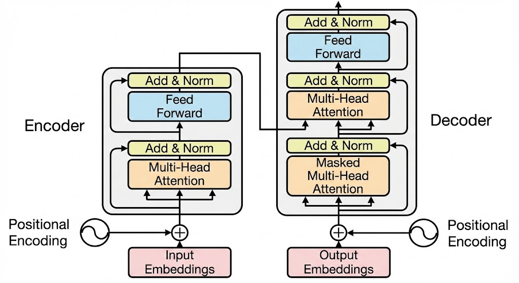

### 4) 트랜스포머의 구조와 핵심원리

#### A. 그림 속 네모 상자 설명

- 그림 소개: 그림에 등장하는 네모 상자들은 데이터를 처리하는 공장의 ’공정’과 같음.

##### 나. add & norm(더하기 및 정규화)

- 위치: 각 어텐션 블록과 피드 포워드 블록 뒤에 붙어 있는 노란색 박스.
- 역할: 학습이 망가지지 않게 돕는 안전장치.
  - add(잔차 연결): 어텐션을 거치면서 원래 문장의 정보가 희석될 수 있음. 그래서 처리 전의 원본 데이터($x$)를 처리 후의 결과($f(x)$)에 더해줌($x + f(x)$). $\Rightarrow$ “원래 의미를 잊지 말라”고 챙겨주는 것.
  - norm(층 정규화): 데이터 값들이 너무 커지거나 작아져서 들쑥날쑥하지 않도록 고르게 다듬어줌. 덕분에 학습이 안정적이고 빠르게 진행됨.

##### 다. feed forward(피드 포워드 신경망)

- 위치: 인코더와 디코더의 파란색 박스.
- 역할: 어텐션을 통해 파악한 단어 간의 관계 정보를 바탕으로, 각 단어의 의미를 심층적으로 가공하고 변환하는 과정. $\Rightarrow$ 우리가 흔히 아는 기본 신경망 층.

#### B. 인코더-디코더 별 해설

- 그림 소개
  - 이 다이어그램은 트랜스포머라는 인공지능 모델이 문장을 어떻게 처리하는지 보여주는 지도임. 트랜스포머는 번역기([EX] 파파고, 구글 번역)나 챗봇([EX] ChatGPT)의 핵심기술로 사용됨.
  - 트랜스포머 모델은 인코더(왼쪽 탑)와 디코더(오른쪽 탑) 두 부분으로 나뉨.
- 예시: 번역기
  - 왼쪽 탑(인코더): 문장을 이해하는 역할
    - 입력(input): 번역할 문장([EX] “나는 학교에 간다”)을 넣음.
    - 단어 벡터 변환(input embedding): 컴퓨터가 이해할 수 있도록 각 단어를 숫자 뭉치(벡터)로 바꿈.
    - 위치정보 추가(positional encoding): 단어의 순서 정보를 더해줌(“나는”이 맨 앞, “간다”가 맨 뒤라는 것을 알려줌).
    - 멀티헤드 어텐션(multi-head attention): **여기가 핵심!** 문장 내에서 어떤 단어들이 서로 중요한 관계인지 파악함(“나”는 “간다”의 주체, “학교에”는 “간다”의 목적지라는 것을 알아챔). 여러 개의 ’헤드(눈)’로 동시에 다양한 관계를 살핌.
    - 정리 및 전달(add & norm, feed forward): 파악한 정보를 잘 정리해서 다음 층으로 넘겨줌. 이 과정을 여러 번 반복하며 문장의 의미를 깊이 있게 이해하게 됨.
  - 오른쪽 탑(디코더): 새로운 문장을 만들어내는 역할
    - 입력(output): 번역될 문장의 앞부분을 넣음. 처음에는 아무것도 없는 상태(`<start>`)에서 시작.
    - 마스크드 어텐션(masked multi-head attention): 지금까지 만들어진 앞부분 단어들만 보고 다음 단어를 예측(아직 안 만들어진 뒷부분은 보지 못하게 가림).
    - 인코더 정보 활용(multi-Head attention): 왼쪽 탑(인코더)이 이해한 원문정보를 가져와서, 지금 만들고 있는 문장과 어떻게 연결되는지 살핌.
    - 단어선택(linear, softmax): 다음에 올 가장 적절한 단어를 확률로 계산하여 선택.
    - 반복: 선택된 단어를 다시 디코더 입력으로 넣고, 문장이 끝날 때까지 이 과정을 반복.
- 요약: 왼쪽(인코더)에서 원문을 깊이 있게 이해하고, 그 정보를 바탕으로 오른쪽(디코더)에서 한 단어씩 적절한 단어를 선택하며 새로운 문장을 만들어내는 것이 트랜스포머의 원리!

## (2) 맥락적 임베딩(contextualized embedding)

- word2vec: 우리가 이전에 배웠던 word2vec은 정적(static) 임베딩임. 사전처럼 ’사과’라는 단어는 항상 고정된 하나의 벡터값을 가짐.
- 트랜스포머: 트랜스포머 기반 임베딩([EX] BERT)은 동적(dynamic) 또는 맥락적 임베딩’임.
- word2vec vs. 트랜스포머 간 차이점
  - word2vec: “배가 고프다”, “배를 타다”의 두 ’배’는 같은 벡터를 가짐.
  - BERT: “배가 고프다”의 ’배(신체)’와 “배를 타다”의 ’배(운송수단)’는 문맥이 다르므로 서로 다른 벡터값을 가짐.
- 이러한 특성 덕분에 트랜스포머 임베딩은 단어의 중의성이나 미묘한 뉘앙스를 훨씬 더 정확하게 포착할 수 있어, 우울증이나 불안과 같은 심리적 상태가 반영된 텍스트 분석에 매우 효과적임.

# 3. Hugging Face(허깅페이스) 소개 및 모델 탐색

## (1) Hugging Face란?

- AI 모델의 GitHub: 전 세계 연구자들과 기업들이 개발한 최신 딥러닝 모델(트랜스포머 포함)과 데이터셋을 공유하는 오픈소스 플랫폼임.
- 표준화된 사용법: 수많은 종류의 모델을 **transformers**라는 라이브러리를 통해 통일된 방식으로 쉽게 가져다 쓸 수 있게 해줌.

## (2) 한국어 사전학습 모델 탐색

- 우리가 모델을 밑바닥부터 학습시키는 것은 엄청난 데이터와 계산자원(GPU)이 필요함. 따라서 이미 대량의 한국어 데이터로 학습이 완료된 **사전학습(pre-trained) 모델**을 가져와 우리 목적에 맞게 사용하는 것이 효율적임.
- [Hugging Face 모델 허브](https://huggingface.co/models)에서 ‘Korean’ 등의 태그로 검색하면 적절한 모델을 찾을 수 있음.

## (3) 수강생 환경(GPU VRAM)을 고려한 모델 추천

### 1) GPU 모델 추천

#### A. 기본 모델

- 모델의 크기가 클수록 성능은 좋지만, 더 많은 VRAM이 필요함. 일반적인 연구실 환경이나 개인 PC(Colab 무료 버전 포함)를 고려하여 적절한 모델을 선택해야 함.
- 기본 모델
  - 권장: VRAM 4GB~8GB 환경. RTX 4060 8GB 시세 44-46만 원.
  - 학습 및 추론 속도가 빠르며 준수한 성능을 보임. 입문용으로 적합함.
- `kykim/bert-kor-base`: 다양한 한국어 데이터로 잘 학습된 BERT base 모델임. 범용적으로 많이 사용됨.
- `monologg/koelectra-base-v3-discriminator`: BERT보다 효율적인 학습 방식(ELECTRA)을 사용한 모델로, 가볍지만 성능이 우수함.
- `klue/roberta-base`: KLUE(한국어 언어 이해 평가 벤치마크) 구축 과정에서 만들어진 고품질 모델임.
- `jhgan/ko-sbert-nli`
  - 문장의 **맥락과 의미**를 파악하는 데 특화된 Sentence-BERT 모델.
  - Sentence-BERT
    - 입력: “나는 슬프다” $\rightarrow$ [‘나’, ‘##는’, ‘슬프’, ‘##다’] $\Rightarrow$ BERT나 SBERT나 똑같음.
    - 출력
      - 기본 BERT: 각 토큰(나, 는, 슬프, 다)마다 각각의 벡터(숫자 덩어리)를 내뱉음. 그래서 문장 전체의 요약본을 만드는 데는 서투름.
      - Sentence-BERT: 단어들을 다 읽은 뒤 해당 문장의 핵심의미, 즉 **문장 전체를 대표하는 하나의 벡터(sentence embedding)**를 생성함.
  - 일반적인 BERT 모델과 달리 문장 전체의 의미를 고품질의 벡터(숫자)로 압축하는 능력이 뛰어나, 문장 간 유사도 비교나 분류 작업에서 훨씬 우수한 성능을 발휘함.

#### B. 대형 모델

- 대형 모델
  - 권장: VRAM 16GB 이상 환경. RTX 4060 Ti 16GB 시세 71-75만 원.
  - 더 깊은 문맥이해가 가능하지만, 일반적인 환경에서는 다루기 어렵고 속도가 느림.
  - 예시: `klue/roberta-large`, `beomi/kcbert-large` 등 이름에 ’large’가 붙은 모델들.
- 오늘 실습에서는 안정적인 실행을 위해 `klue/roberta-base` 또는 `jhgan/ko-sbert-nli` 같은 기본(base) 사이즈 모델을 사용할 것임.

### 2) 그래픽 카드 이름 해석하기

- **RTX**
  - 설명: 엔비디아(NVIDIA)가 2018년부터 도입한 그래픽 카드 라인업의 명칭으로, 기존의 GTX 라인업을 대체하는 상위 브랜드.
  - RTX의 기술적 의미
    - Real-time Ray Tracing(실시간 광선 추적) 기술.
    - Ray Tracing(광선 추적): 빛이 물체에 반사되거나 투과되는 경로를 현실처럼 시뮬레이션하여, 거울에 비친 모습이나 물 웅덩이의 반사 등을 영화처럼 사실적으로 표현하는 기술.
    - 기존 GTX 시리즈는 이 기술을 하드웨어적으로 처리하기 버거웠으나, RTX 시리즈부터는 **RT 코어(Ray Tracing Core)**라는 전용 칩을 탑재하여 게임 중에도 실시간으로 처리할 수 있게 되었음.
  - RTX의 풀네임
    - **R**ay Tracing **T**exel e**X**treme
      - **R**ay **T**racing: 광선 추적 기술(핵심기능).
      - **T**exel: 텍셀(Texel, 텍스처의 화소 단위) 처리 능력.
      - e**X**treme: 극한의 성능
- **40**60:
  - 설명: 앞의 숫자 40은 ’세대(generation)’를 의미.
  - 의미: 이 제품이 언제, 어떤 기술(아키텍처)로 만들어졌는지를 나타냄. 숫자가 높을수록 최신형.
  - 예시: **30**60(이전 세대) $\rightarrow$ **40**60 (현재 세대) $\rightarrow$ **50**60(미래 세대)
  - 참조: 40시리즈는 엔비디아의 ’에이다 러브레이스(Ada Lovelace)’라는 최신 아키텍처를 사용.
- 40**60**
  - 설명: 뒤의 숫자 60은 해당 세대 내에서의 성능등급(tier)을 의미.
  - 의미: 같은 40시리즈 형제들 중에서 이 녀석의 서열이 어디인지를 나타냄. 숫자가 높을수록 고성능(그리고 비싼) 모델임.
  - 등급 구분
    - 50: 보급형(문서 작업, 가벼운 게임용).
    - 60: 메인스트림(대중적인 게임용, FHD 해상도 최적화).
    - 70: 고사양(QHD 해상도 게임용).
    - 80~90: 초고사양(4K 해상도, 전문가 작업용).
- **Ti**
  - 설명: 이름 뒤에 붙은 Ti는 원소 기호 티타늄(Titanium)의 약자.
  - 의미: 기본 모델보다 성능이 업그레이드된 버전이라는 뜻.
  - 관계: 성능 순서는 RTX 4060 $<$ RTX 4060 Ti $<$ RTX 4070 순.
  - 특징: 일반 4060보다 코어 개수가 많거나 메모리 성능이 더 좋아 게임 프레임이 더 잘 나옴.

### 3) 그래픽 카드가 딥 러닝의 기본전제가 된 이유

- 구조적 이유: “대량의 단순노동”에 최적화
  - CPU(똑똑한 소수정예): 복잡한 논리연산, 순차적 처리, 분기 예측(if문) 등에 강함. 코어 수는 적지만(수십 개), 각 코어의 성능이 매우 뛰어남.
  - GPU(단순한 수천 명의 일꾼): 원래 모니터의 수백만 개 픽셀에 색상 값을 동시에 뿌려주기 위해 만들어짐. 개별 코어의 지능은 낮지만, 코어 수가 수천 개([EX] RTX 4090은 16,384개)에 달함.
  - 딥 러닝의 본질과의 만남
    - 딥 러닝은 거창해 보이지만, 수학적으로 뜯어보면 수백 만~수조 개의 파라미터에 대한 단순 행렬 곱셈과 덧셈의 무한반복임.
    - 복잡한 논리판단보다는, “이 숫자들을 동시에 곱하고 더해라”라는 명령을 수천 번 수행해야 함.
    - 이 작업에서 CPU는 마치 ’수학교수 10명이 100만 개의 덧셈 문제를 푸는 것’처럼 비효율적이지만, GPU는 초등학생 10,000명이 동시에 문제를 하나씩 푸는 것처럼 압도적으로 빠름.
- 역사적 계기: GPGPU와 알렉스넷(AlexNet) 혁명
  - GPU가 게임용을 넘어 연산용으로 쓰이게 된 두 가지 결정적 사건이 있음.
  - CUDA의 등장(2006년)
    - 엔비디아는 CUDA(Compute Unified Device Architecture)라는 플랫폼을 내놓음.
    - 이전까지는 GPU를 쓰려면 그래픽 명령어로 어렵게 우회해야 했지만, CUDA 덕분에 연구자들은 C언어 같은 일반 프로그래밍 언어로 GPU의 병렬연산 능력을 직접 끌어다쓸 수 있게 됨. 이를 GPGPU(General-Purpose computing on GPU)라고 함.
  - AlexNet의 충격(2012년)
    - 딥 러닝의 빅뱅이라 불리는 사건. 제프리 힌튼 교수의 제자 알렉스 크리제브스키(Alex Krizhevsky)가 이미지 인식 대회(ImageNet)에서 AlexNet을 선보여 압도적인 1등을 차지.
    - 당시 그는 GTX 580이라는 게임용 그래픽 카드 2장을 병렬로 연결해 모델을 학습시킴.
    - CPU로 몇 달이 걸릴 연산을 GPU를 통해 6일 만에 끝냄.
    - 이 사건 이후 전 세계 AI 연구자들은 “딥 러닝에는 GPU가 필수”라는 사실을 깨닫고, 모든 연구실이 엔비디아 GPU를 사들이기 시작함.
- 요약
  - 그래픽 카드는 원래 화면의 픽셀(점)들을 동시에 계산하기 위해 만들어졌음. 그런데 알고 보니 딥 러닝이 필요로 하는 신경망의 가중치(숫자)들을 동시에 계산하는 일과 그 구조가 쌍둥이처럼 닮아 있었던 것.
  - 결국 수천 개의 코어로 행렬연산을 병렬 처리하는 능력(parallel processing)이 GPU를 단순한 게임 장비에서 인공지능 시대의 핵심 엔진으로 격상시킴.
  - 결론: 젠슨 황, 소 뒷걸음질치다 쥐 잡았당! 알렉스한테 밥 사라..

# 4. R 환경 설정 및 데이터 준비

- Hugging Face 라이브러리는 파이썬 기반임. R에서 이를 활용하기 위해 **reticulate** 패키지를 통해 파이썬 환경을 연결하고, R 코드로 파이썬 객체와 함수를 제어하는 방식으로 실습을 진행함.

## (1) 필수 패키지 로드 및 파이썬 환경 연결

```r
# -----------------------------------------------------------------------------
# 1. R 필수 패키지 로드
# -----------------------------------------------------------------------------
library(tidyverse)
library(jsonlite)
library(reticulate)
library(furrr) # tidyverse의 purrr 패키지 함수들을 병렬처리 방식으로 실행하여 속도를 높여주는 패키지(대량 데이터 처리에 유용).
library(parallel)

# -----------------------------------------------------------------------------
# 2. 파이썬 가상환경 설정
# -----------------------------------------------------------------------------

use_condaenv("my_env_310", required = TRUE) # 여러분이 keras3와 tensorflow를 설치한 conda 환경을 불러올 것.

# -----------------------------------------------------------------------------
# 3. 파이썬 필수 라이브러리 설치 및 확인 안내
# -----------------------------------------------------------------------------
# 실습을 진행하기 전에 아래의 파이썬 라이브러리들이 해당 환경에 설치되어 있어야 함.
# transformers: Hugging Face 모델 사용을 위한 핵심 라이브러리
# torch: 딥러닝 프레임워크 PyTorch
# numpy: 수치 계산을 위한 라이브러리
# pandas: 데이터 데이터 조작을 위한 라이브러리(Hugging Face Dataset 변환 시 필요)
# peft: 효율적인 미세조정(LoRA 등)을 위한 라이브러리
# accelerate: 학습 속도 가속 및 최적화를 위한 라이브러리

# 설치방법: R에서 직접 설치를 시도할 경우 아래 명령어를 사용. 반드시 ㅁ리 파이썬 가상환경을 설정한 후에 설치할 것.
# py_install(c("transformers", "torch", "numpy", "pandas", "peft", "accelerate", "sentence_transformers"), pip = TRUE)

# -----------------------------------------------------------------------------
# 4. 파이썬 라이브러리를 R 환경으로 불러오기(import)
# -----------------------------------------------------------------------------
# reticulate 패키지의 import() 함수를 사용하여 파이썬 모듈을 R 객체로 불러옴.
transformers <- import("transformers") # Hugging Face Transformers 불러오기
torch <- import("torch") # PyTorch 불러오기
np <- import("numpy") # NumPy 불러오기
peft <- import("peft") # PEFT(LoRA용) 불러오기

# -----------------------------------------------------------------------------
# 5. 병렬처리 설정(선택사항)
# -----------------------------------------------------------------------------
# 대량의 텍스트 데이터를 임베딩할 때 속도를 높이기 위해 병렬처리 설정.
# detectCores(): 현재 컴퓨터의 CPU 코어 개수를 탐지.
# 코어 하나는 시스템 유지를 위해 남겨두고 나머지 코어를 사용하도록 설정.
plan(multisession, workers = parallel::detectCores() - 1)
```

## (2) 데이터 로드 및 전처리

- AI 허브의 심리상담 데이터셋(JSON 파일 1325개)을 로딩하고 전처리함.

```r
library(googledrive)
library(jsonlite)
library(tidyverse)
# -----------------------------------------------------------------------------
# 1. 데이터셋 다운로드 받고 파일 목록 준비하기
# -----------------------------------------------------------------------------

# (0) 다운받을 파일을 저장할 폴더 만들기

dir.create("DL_text", recursive = T)

# (1) 라이브러리 로드
library(googledrive)

# (2) 구글 드라이브 인증
drive_auth()

# (3) 구글 드라이브 공유 ID를 file_id 객체에 할당하기
file_id <- "1vY6axoKXEkx2XLFVKPAa2nyr62_3OuIF"

# (4) 파일 다운로드
drive_download(as_id(file_id), path = "DL_text/심리상담_라벨링데이터_training.zip", overwrite = TRUE)

# (5) 다운로드한 압축파일 워킹 디렉토리에 압축 풀기
unzip("DL_text/심리상담_라벨링데이터_training.zip", exdir = "DL_text", overwrite = TRUE)

# (6) 파일 목록 준비
DL_files <- list.files(path = "DL_text", pattern = "json$", full.names = TRUE, recursive = TRUE)

# -----------------------------------------------------------------------------
# 2. JSON 파일을 읽어서 데이터프레임으로 변환하는 함수 정의
# -----------------------------------------------------------------------------
read_mental_health_json <- function(filepath) {
  tryCatch({
    # 1. JSON 파일 읽기
    json <- fromJSON(filepath)

    # 2. 내담자 발화만 추출 및 병합
    # json$paragraph는 데이터프레임임. 여기서 먼저 필터링을 해야 힘.
    client_text <- json$paragraph %>%
      as_tibble() %>%  # 안전하게 티블로 변환
      filter(paragraph_speaker == "내담자") %>% # '내담자'인 행만 남김
      pull(paragraph_text) %>% # 텍스트 컬럼만 뽑아서 벡터로 만듦
      str_c(collapse = " ") # 하나의 긴 문자열로 합침

    # 3. 결과 반환 (텍스트 + 라벨)
    tibble(
      filename = basename(filepath), # (선택사항) 파일명도 같이 기록하면 추적하기 좋음
      text = client_text, # 합쳐진 내담자 발화
      label = json$class # 증상 라벨([EX] DEPRESSION)
    )

  }, error = function(e) {
    # 에러 발생 시 메시지 출력 및 NULL 반환
    message(paste("Error reading file:", filepath))
    return(NULL)
  })
}

# -----------------------------------------------------------------------------
# 3. 전체 데이터 로드 및 병합 파이프라인
# (주의: 오류 파일이 26개가 되니 오류 메시지가 이어지더라도 놀라지 말 것)
# -----------------------------------------------------------------------------
df_full <- DL_files %>%
  # map_dfr(): DL_files 벡터의 각 파일 경로에 대해 read_mental_health_json 함수를 적용(map)하고,
  # 그 결과로 나온 데이터프레임들을 행 방향으로 합쳐서(dfr: data frame row-bind) 하나의 큰 데이터프레임을 만듦.
  map_dfr(read_mental_health_json) %>%
  # mutate(): label 열의 데이터를 문자열에서 팩터(범주형 변수)로 변환함. 모델 학습에 필요함.
  mutate(label = factor(label)) %>%
  # filter(): 혹시 모를 빈 텍스트(글자 수가 0인 경우)를 제거하여 데이터의 품질을 높임.
  filter(nchar(text) > 0)
save(df_full, file="df_full.rda")

# df_full 파일 URL
df_full_url <- "https://raw.githubusercontent.com/cognitivepsychology/NLP_2025/main/data/df_full.rda"
# 로컬에 저장할 파일명
df_full_file <- "df_full.rda"
# df_full.rda 다운로드하기
download.file(df_full_url, df_full_file)
# 다운받은 df_full 객체 로드하기
load("df_full.rda")

# -----------------------------------------------------------------------------
# 4. 데이터 확인 및 분리(train/test)
# -----------------------------------------------------------------------------
# 전체 데이터 개수 출력
nrow(df_full)

# 데이터의 앞부분 일부 확인
df_full

# 각 라벨별 데이터 개수(분포) 확인
table(df_full$label)

# 재현성 확보를 위해 난수 생성 시드를 고정함. 매번 같은 결과가 나오게 함.
set.seed(123)

# 학습용 데이터로 사용할 인덱스를 label별로 무작위 샘플링함.
# 전체 데이터의 label별로 80%씩 비복원 추출함.
train_index <- df_full %>%
  rownames_to_column() %>% # 행 번호를 칼럼으로 만들기.
  mutate(rowname = as.integer(rowname)) %>% # 문자열로 되어 있는 행 번호를 정수로 바꾸기.
  group_by(label) %>% # label에 따라 그룹화하기.
  slice_sample(prop = 0.8) %>% # label별로 80퍼센트씩 샘플링하기.
  pull(rowname) # 행 번호만 벡터로 추출하기.

# 추출한 인덱스를 사용하여 학습용 데이터셋(df_train)을 만듦.
df_train <- df_full[train_index, ]
# 추출되지 않은 나머지 인덱스(마이너스 기호 사용)를 사용하여 테스트용 데이터셋(df_test)을 만듦.
df_test <- df_full[-train_index, ]

# label(정답) 열을 숫자에서 요인 범주로 바꾸기.
df_train$label <- as.factor(df_train$label)
df_test$label  <- as.factor(df_test$label)

save(df_train, file="df_train.rda")
save(df_test, file="df_test.rda")

# 분리된 각 데이터셋의 개수를 확인함.
nrow(df_train) # 학습 데이터 개수
nrow(df_test) # 테스트 데이터 개수

# df_train 파일 URL
df_train_url <- "https://raw.githubusercontent.com/cognitivepsychology/NLP_2025/main/data/df_train.rda"
# 로컬에 저장할 파일명
df_train_file <- "df_train.rda"
# df_train.rda 다운로드하기
download.file(df_train_url, df_train_file)
# 다운받은 df_train 객체 로드하기
load("df_train.rda")

# df_test 파일 URL
df_test_url <- "https://raw.githubusercontent.com/cognitivepsychology/NLP_2025/main/data/df_test.rda"
# 로컬에 저장할 파일명
df_test_file <- "df_test.rda"
# df_test.rda 다운로드하기
download.file(df_test_url, df_testn_file)
# 다운받은 df_train 객체 로드하기
load("df_test.rda")
```

# 5. Hugging Face 모델로 임베딩 추출하기

- R에서 **reticulate** 패키지를 통해 파이썬의 **transformers** 라이브러리를 불러와서 사전학습 모델을 로드하고 텍스트를 임베딩 벡터로 변환함.
- 우리가 사용할 딥 러닝 임베딩 추출을 위해 사용할 모델은 `jhgan/ko-sbert-nli`임.

## (1) 두 모델의 차이: 어휘력 vs. 문해력

### 1) 기초 모델: klue/roberta-base

- 비유: 어휘력이 뛰난 국어국문학 전공생.
- 학습방식(masked language modeling)
  - 이 친구는 도서관에 있는 수만 권의 한국어 책을 읽으면서 “빈칸 채우기” 연습을 엄청나게 힘.
  - 예시: “나는 오늘 기분이 너무 [ ] 싶어.” $\rightarrow$ 정답: “우울해서 죽고”
- 특징
  - 단어의 앞뒤 문맥을 파악하는 능력이 매우 뛰어님. 문법도 완벽함.
  - 하지만 “문장 전체의 요점(의미)”을 한 줄로 요약해보라고 하면 조금 서투름.
  - 비유하자면, 사전적 의미는 완벽하게 알지만, 내담자의 말 속에 숨겨진 ’핵심정서’를 덩어리로 묶는 훈련은 받지 않은 상태임.
- SVM에게 주는 정보: 이 모델이 만든 임베딩은 ’단어들의 나열’에 가까움. SVM이 이걸 보고 분류하려면 조금 헤매게 됨.

### 2) SBERT 모델: jhgan/ko-sbert-nli

- 비유: 임상 훈련을 마친 심리상담 전문가.
- 학습방식(matural language inference): 이 친구는 위 전공생(`roberta`)을 데려다가 대학원에서 특수훈련을 더 시킨 것. 두 문장을 보여주고 “이 두 문장이 같은 뜻이야, 다른 뜻이야?”를 맞히는 훈련을 함.
  - 문장 A: “삶이 너무 고달프고 힘들어요.”
  - 문장 B: “죽고 싶다는 생각이 들 정도로 괴로워요.”
  - 정답: “유사함(비슷한 호소임).”
- 특징
  - 단어 하나하나보다는 “문장 전체가 풍기는 뉘앙스(meaning)”를 숫자로 바꾸는 데 특화되어 있음.
  - 단어가 달라도 의미가 같으면 비슷한 숫자(벡터)로 변환함.
- SVM에게 주는 정보: 이 모델이 만든 임베딩은 ’의미의 좌표’임. 우울한 문장끼리는 똘똘 뭉쳐있고, 행복한 문장은 멀리 떨어져 있음.

### 3) 시각적 비교: SVM이 바라보는 세상

- 이 차이를 그림으로 상상해보자. SVM은 두 집단을 가르는 선(경계선)을 긋는 역할을 함.
- 상황 A: `klue/roberta-base`를 썼을 때
  - 데이터들이 ‘단어’ 위주로 흩어져 있음.
  - “힘들다(우울)”와 “힘내자(일반)”가 ’힘’이라는 글자가 같다는 이유로 서로 가까이 붙어 있음.
  - 결과: SVM이 선을 긋기가 너무 어려움. 억지로 긋다 보니 정확도가 떨어짐.
- 상황 B: `jhgan/ko-sbert-nli`(SBERT)를 썼을 때
  - 데이터들이 ‘의미’ 위주로 뭉쳐 있음.
  - “힘들다”는 “괴롭다” 옆에 가 있고, “힘내자”는 “파이팅” 옆에 가 있음.
  - 결과: 우울한 문장 그룹과 일반 문장 그룹이 확연히 갈라져 있음. SVM이 그 사이에 쉽게 선을 그을 수 있음.

### 4) 결론

- 만약 모델이 전체적인 텍스트의 의미를 제대로 파악했는지 검증하는 것이 목적이라면 문장의 ’의미’를 가장 잘 이해하는 전문가 모델인 SBERT를 쓰는 것이 훨씬 타당함.

**[표 2] 기본 모델과 SBERT 모델 간 비교**

| 구분 | 기본 모델(klue/roberta-base) | SBERT 모델(jhgan/ko-sbert-nli) |
| --- | --- | --- |
| 비유 | 사전을 통달한 학생 | 의미를 통달한 상담사 |
| 주특기 | 빈칸 채우기, 문법 파악 | 문장 간 유사도 비교, 요점 파악 |
| 벡터의 성격 | 단어의 기계적 조합(평균) | 의미가 압축된 정제된 정보 |
| SVM 성능 | 보통(데이터가 복잡하면 낮아짐) | 매우 좋음(데이터가 깔끔하게 정렬됨) |

## (2) 토크나이저 및 모델 로드

- 토크나이저(`tokenizer`): 텍스트를 모델이 이해할 수 있는 숫자(토큰 ID) 시퀀스로 변환함.
- 모델(`model`): 토큰 ID 시퀀스를 입력받아 고차원의 은닉상태(hidden state) 벡터를 출력함.
- `model$eval()`
  - 학습 모드: 시험공부를 하는 학생. 다양한 학습방법(드롭아웃 등)을 사용하여 실력을 키움.
  - 평가 모드: 시험을 보는 학생. 컨닝(드롭아웃 등)을 하지 않고, 평소 실력으로 시험에 임함
  - 결론: 모델이 학습과정에서 사용했던 기법들을 **비활성화**하여, 실제 데이터에 대한 예측성능을 정확하게 평가할 수 있도록 준비하는 과정임.
- `AutoTokenizer$from_pretrained()` / `AutoModel$from_pretrained()`
  - 역할: Hugging Face Hub에서 사전학습된 토크나이저와 모델을 다운로드하고 로드함.
  - 논항: `pretrained_model_name_or_path` $\Rightarrow$ 모델의 ID([EX] “klue/roberta-base”).
- `model$to()`
  - 역할: 모델을 특정 연산장치(CPU 또는 GPU)로 이동시킴.
  - 논항: `"cpu"` 또는 `"cuda"`(GPU).
- `tokenizer()`
  - 역할: 텍스트를 모델 입력 형식으로 변환함.
  - 논항
    - `text`: 변환할 텍스트 리스트.
    - `padding`: 배치 내 길이를 맞추기 위해 패딩 토큰을 추가할지 여부(`TRUE`/`FALSE`).
    - `truncation`: 최대 길이를 초과하는 문장을 자를지 여부(`TRUE`/`FALSE`).
    - `return_tensors`: 반환할 텐서 형식(`"pt"`는 PyTorch, `"np"`는 NumPy).

```r
# -----------------------------------------------------------------------------
# 1. 사용할 Hugging Face 모델 ID 지정
# -----------------------------------------------------------------------------
# SBERT 모델인 jhgan/ko-sbert-nli 모델을 사용함.
model_name <- "jhgan/ko-sbert-nli"

# -----------------------------------------------------------------------------
# 2. 파이썬 transformers 라이브러리를 활용한 로드
# -----------------------------------------------------------------------------

# AutoTokenizer$from_pretrained(): 해당 모델에 맞는 토크나이저를 자동으로 다운로드하고 불러옴.
# 토크나이저는 텍스트를 모델이 이해할 수 있는 숫자 ID로 변환하는 역할을 함.
tokenizer <- transformers$AutoTokenizer$from_pretrained(model_name)

# AutoModel$from_pretrained(): 사전학습된 기본 모델(base model)을 자동으로 다운로드하고 불러옴.
# 이 모델은 임베딩 추출 용도로만 사용됨.
model <- transformers$AutoModel$from_pretrained(model_name)

# -----------------------------------------------------------------------------
# 3. 모델 실행 장치 설정(GPU/CPU) 및 모드 전환
# -----------------------------------------------------------------------------
# torch$cuda$is_available(): 현재 환경에서 GPU(CUDA) 사용이 가능한지 확인함.
# 사용 가능하다면 "cuda", 아니면 "cpu"로 디바이스 이름을 설정함.
device <- ifelse(torch$cuda$is_available(), "cuda", "cpu")

# model$to(): 불러온 모델을 설정한 디바이스(GPU 또는 CPU)의 메모리로 이동시킴.
model$to(device)

# model$eval(): 모델을 평가(inference) 모드로 설정함.
# 드롭아웃(dropout) 등 학습 때만 필요한 기능들이 비활성화되어 일관된 임베딩을 얻을 수 있음.
model$eval()
```

- 왜 일부 가중치가 포함되지 않은 채 불완전하게 로드될까?
  - 비유: “언어천재”와 “신입 상담사”
  - 사전학습 모델(body): 엄청나게 똑똑한 언어천재임. 한국어의 문법, 단어 뜻, 문맥파악 능력은 이미 만렙. 이 부분의 지식(가중치)은 완벽하게 로드됨.
  - 분류기/풀러(head/pooler): 이 천재가 수행해야 할 구체적인 업무 도구임.
    - 원래 모델은 ’빈칸 채우기(masked language modeling)’라는 시험을 보던 친구였음.
    - 그런데 선생님이 이 친구를 데려와서 갑자기 ’심리상담 분류’라는 새로운 업무를 시키려고 함.
    - 당연히 이 친구는 “저는 한국어는 잘 알지만, 상담분류는 처음인데요? 이 업무용 도구(pooler/classifier)는 새로 세팅해야겠네요.”라고 말하는 것.

## (3) 임베딩 추출 함수 정의

### 1) 어텐션 마스크(attention mask)

- R에서 텍스트 리스트를 받아 임베딩 행렬을 반환하는 R 함수를 정의함.
  - [CLS] 토큰: BERT 계열 모델에서 문장 맨 앞에 붙는 특수 토큰. 이 토큰의 최종 은닉상태 벡터는 **문장 전체의 의미를 요약**하는 역할을 한다고 간주되어 주로 문장 임베딩으로 사용됨.
  - 배치(batch) 처리: 대량의 데이터를 한 번에 처리하면 메모리 부족 오류가 발생할 수 있음. 따라서 데이터를 작은 묶음(배치)으로 나누어 처리해야 함.
- 어텐션 마스크
  - 패딩
    - 딥러닝 모델은 효율적인 병렬처리를 위해 입력 데이터가 **동일한 길이의 행렬(배치)** 형태로 들어오기를 기대함.
    - 이를 위해 가장 긴 문장의 길이에 맞춰 짧은 문장의 뒷부분을 특정한 값(보통 0)으로 채우는 작업을 패딩이라고 함.
  - 문장의 최대 길이를 5로 정할 경우
    - 문장 A: [나, 는, 사과, 를, 좋아해] $\Rightarrow$ 길이 5.
    - 문장 B: [배고파, ., 0, 0, 0] $\Rightarrow$ 뒤에 0을 채워 길이 5로 맞춤.
  - 트랜스포머 모델의 핵심인 어텐션 메커니즘은 문장 내의 모든 단어 쌍 사이의 관계를 계산함.
    - 문제점: 모델이 의미 없는 패딩 토큰(0)들까지도 다른 실제 단어들과 어떤 관계가 있는지 계산하려고 시도함. 이는 두 가지 문제를 일으킴.
      1. 계산낭비: 불필요한 연산을 수행하여 학습속도가 느려짐.
      2. 성능저하: 패딩 토큰의 (의미 없는) 정보가 실제 단어의 정보에 섞여 들어가 모델의 판단을 흐리게 만들 수 있음.
  - 정의: 어텐션 마스크는 입력 시퀀스와 동일한 길이의 0과 1로 구성된 텐서(배열)임.
  - 역할: 모델에게 “어떤 토큰이 진짜 정보(1)이고, 어떤 토큰이 무시해야 할 패딩(0)인지”를 알려주는 신호등 역할을 함.
    - `1`: 실제 단어이므로 어텐션 계산에 포함시켜라.
    - `0`: 패딩 토큰이므로 어텐션 계산에서 제외시켜라(마스킹해라).
  - 예시
    - 입력 토큰 ID(`input_ids`): [배고파(ID:101), .(ID:102), 0(패딩), 0(패딩), 0(패딩)].
    - 어텐션 마스크(`attention_mask`): [1, 1, 0, 0, 0].
  - 모델은 이 `attention_mask`를 보고 값이 0인 위치의 토큰들과는 어텐션 점수를 계산하지 않거나, 계산된 점수를 강제로 음의 무한대로 만들어 소프트맥스(softmax) 함수 통과 시 결과가 0이 되도록 만듦. $\Rightarrow$ 결과적으로 패딩 토큰은 모델의 정보처리에 아무런 영향을 주지 않게 됨.
  - 요약
    - 입력 문장의 길이를 맞추기 위해 추가된 의미 없는 패딩 토큰들을 모델이 불필요하게 처리하지 않도록, 실제 정보가 있는 부분(1)과 무시해야 할 부분(0)을 표시해둔 신호등 같은 배열이라는 의미.
    - 이 덕분에 모델은 효율적이고 정확하게 실제 문장의 의미에만 집중할 수 있게 됨.

### 2) last_hidden_state(최종 은닉상태)의 차원

#### A. 차원별 설명

- 첫 번째 차원(배치 크기): 한 번에 처리하는 문장의 개수([EX] 32개 문장).
- 두 번째 차원(시퀀스 길이): 각 문장에 포함된 토큰(단어 조각)의 개수([EX] 최대 128개 토큰).
- 세 번째 차원(은닉 벡터 차원)
  - 각 토큰 하나하나를 표현하는 숫자들의 개수([EX] BERT base 모델의 경우 768개). $\Rightarrow$ 첫 번째 토큰([CLS] 토큰)이 가지고 있는 **모든 은닉 벡터 차원([EX] 768개의 숫자 전부)**을 다 선택하겠다는 의미!
  - 왜 첫 번째 토큰([CLS] 토큰)이 가진 모든 은닉 벡터 차원을 선택해야 할까? $\Rightarrow$ 왜냐하면 그 768개의 숫자 묶음(벡터) 전체가 [CLS] 토큰이 가진 의미를 표현하기 때문. 이 768개의 숫자가 모두 있어야 비로소 [CLS] 토큰이 요약한 “문장 전체의 의미”를 온전하게 표현할 수 있음.

#### B. [CLS] 토큰의 역할

##### 가. 문장이라는 이름의 회의

- 의문: “[CLS]라는 특수 토큰 하나가 가진 768개의 숫자(벡터)”가 어떻게 문장 전체의 의미를 담아내는 것일까?
- 상황 비유: “문장”이라는 이름의 회의
  - 상황: 5명이 모여서 회의를 함(문장 길이가 5라고 가정).
  - 참석자(일반 토큰): “나”, “는”, “학교”, “에”, “간다”(각각의 단어들).
  - 서기([CLS] 토큰): 회의내용을 요약하기 위해 참석한 특수 관리자.
- Step 1: 초기상태(입력)
  - 참석자들은 각자의 생각만 가지고 있음(“나”는 ’나’만 생각, “학교”는 ’학교’만 생각).
  - 서기([CLS])는 아무런 정보가 없는 빈 노트(초기 벡터)를 들고 앉아 있음.
- Step 2: 회의진행(self-attention & layer 통과)
  - 트랜스포머의 층(layer)을 통과한다는 것은 **토론**을 하는 것과 같음.
  - 어텐션의 마법
    - “간다”는 “나”와 “학교”의 말을 듣고, “아, 내가 가는 거구나”라고 문맥을 파악함.
    - 가장 중요한 점: 서기([CLS])는 회의 내내 모든 참석자(“나”, “는”, “학교”, “에”, “간다”)의 발언을 경청(attention)함.
- Step 3: 최종상태(last_hidden_state)
  - 회의종료(마지막 레이어 통과).
  - 일반 토큰들의 벡터: 각 단어의 의미에 문맥까지 가미된 정보가 됨.
  - 서기([CLS])의 벡터: 서기의 노트에는 **회의 전체의 내용이 요약**되어 적혀 있음.
  - 서기 본인은 “의미”가 없었지만, 다른 모든 단어의 정보를 빨아들여서 **이 문장은 ’등교’에 관한 이야기다**라는 압축된 정보를 갖게 된 것.

##### 나. 차원으로 다시 보기

- `last_hidden_state`는 3차원 큐브 텐서 $\Rightarrow$ (문장 개수, 토큰 개수, 은닉 벡터 차원 768).
1. `last_hidden_state` 전체
   - 모든 토큰(서기 포함)의 최종상태.
   - 이걸 다 쓰면 정보량은 많지만, 분류기(로지스틱 회귀 등)에 넣기에는 너무 큼(토큰 수 $\times$ 768).
2. `last_hidden_state[, 0L, ]`(우리가 선택한 것)
   - 0번째 토큰([CLS], 서기)의 벡터만 쏙 뽑아냄.
   - 이것은 768개의 숫자로 이루어진 1차원 벡터(막대기)임.
   - 핵심: 이 768개의 숫자는 **서기가 회의(문장) 전체를 듣고 요약한 내용**임.

##### 다. 왜 [CLS]만 뽑아도 되는가?

- 768차원의 벡터들이 토큰 개수만큼 모여야 문장 전체를 완벽하게 설명하는 것이 물리적으로는 맞음.
- 하지만 BERT(트랜스포머) 모델은 학습될 때, **맨 앞에 있는 [CLS] 토큰 하나만 봐도 문장 전체를 분류할 수 있도록** 훈련받음. 즉 모델 내부에서 모든 정보가 [CLS] 토큰의 768개 숫자 안으로 압축되도록 강제된 것.
- 요약
  - 질문: 768개짜리 벡터 하나가 문장 전체를 의미하는가?
  - 답변: 그렇다! 단, 그 벡터가 [CLS] 토큰의 벡터일 때만 그렇다. 이 토큰은 **문장 전체의 정보를 흡수하는 스펀지** 역할을 하도록 설계되었기 때문.

##### 마. 함수 및 코드 설명

- 128L의 비밀
  - R에서는 그냥 숫자 128을 쓰면 실수(float, 128.0)로 취급함.
  - 파이썬은 깐깐해서 정수 자리에 실수가 오면 에러를 냄. 그래서 ‘이건 정수(integer)야!’ 라고 알려주기 위해 뒤에 L을 붙이는 것임.”
- `torch$no_grad()`: “우리는 지금 시험을 보는 중(예측)이지, 공부하는 중(학습)이 아님. 공부할 때는 뭘 틀렸는지 오답 노트(기울기[gradient] 계산)를 써야 하지만, 시험 볼 때는 답만 적어내면 됨. 이 코드는 ’오답 노트 쓰지 말고 답만 빨리 내!”라고 컴퓨터에게 말하는 것임.
- `detach()$cpu()$numpy()`
  - “이건 파이썬이라는 외국에서 만든 데이터를 R이라는 우리나라로 수입해오는 통관절차임.
  - GPU 공장에서 꺼내서(detach), 트럭에 싣고(cpu), 포장을 규격에 맞게 바꾼 뒤(numpy) 가져오는 과정!

```r
# -----------------------------------------------------------------------------
# R 함수 정의: 텍스트 리스트를 받아 (S)BERT 임베딩 행렬을 반환하는 함수
# -----------------------------------------------------------------------------
# texts_list: 임베딩할 텍스트들이 담긴 문자열 벡터 또는 리스트
# tokenizer, model: 앞서 로드한 파이썬 토크나이저 및 모델 객체
# batch_size: 한 번에 처리할 문서의 수(VRAM 메모리 관리를 위해 중요, 기본값 32)
# device: 계산을 수행할 장치("cuda" 또는 "cpu")
# ==============================================================================
# 함수 이름: get_bert_embeddings_r()
# 기능: R의 텍스트 데이터를 받아, 파이썬의 BERT 모델을 통과시켜 임베딩 행렬(매트릭스)로 반환함.
# ==============================================================================

get_bert_embeddings_r <- function(text_data, tokenizer, model, batch_size = 32, max_length = 128L, device = "cpu") {

  # ----------------------------------------------------------------------------
  # 1. 입력 데이터 안전장치 및 초기 설정
  # ----------------------------------------------------------------------------

  # 입력받은 텍스트가 혹시 Factor나 다른 형태일 수 있으므로, 강제로 문자열 벡터로 변환함.
  # (파이썬의 토크나이저는 순수한 문자열 리스트만 처리할 수 있기 때문임)
  text_data <- as.character(text_data)

  # 전체 문장의 개수(N)를 저장함([EX] 1000개 문장)
  n <- length(text_data)

  # 배치(Batch) 처리를 위해 결과를 모아둘 '빈 리스트'를 하나 만듦.
  # (R의 리스트는 파이썬의 리스트와 호환성이 좋아서 임시 저장소로 적합함)
  embeddings_list <- list()

  # ----------------------------------------------------------------------------
  # 2. 배치 단위 반복 처리 시작
  # ----------------------------------------------------------------------------
  # seq(1, n, by = batch_size) -> 1, 33, 65... 식으로 시작 인덱스를 생성함.
  for (i in seq(1, n, by = batch_size)) {

    # 현재 배치의 끝 인덱스를 계산함.
    # min()을 쓰는 이유: 마지막 배치는 32개가 안 될 수도 있으므로, 전체 개수 n을 넘지 않게 함.
    end_idx <- min(i + batch_size - 1, n)

    # 전체 데이터에서 이번에 처리할 만큼만 '슬라이싱'해서 가져옴.
    batch_text <- text_data[i:end_idx]

    # [중요] 여기서부터 파이썬(PyTorch)의 영역임! ----------------------------------

    # 3. 토큰화(tokenizer)
    # R에서 파이썬 객체인 tokenizer를 함수처럼 호출함.
    encoded_input <- tokenizer(
      text = batch_text, # 이번에 처리할 문장들
      padding = TRUE, # 문장 길이를 제일 긴 놈(혹은 max_length)에 맞춰 0으로 채움
      truncation = TRUE, # 너무 긴 문장은 자름
      max_length = max_length, # 최대 길이 설정(R에서 정수형은 숫자 뒤에 L을 붙여야 파이썬 int로 정확히 전달됨)
      return_tensors = "pt" # 결과를 'PyTorch 텐서' 형식으로 달라고 요청함
    )

    # 4. GPU/CPU 이동
    # 만들어진 토큰 데이터를 계산 장치(GPU 등)로 옮김.
    # encoded_input은 딕셔너리 형태이므로 $to(device)를 호출하여 통째로 이동시킴.
    encoded_input <- encoded_input$to(device)

    # 5. 모델 통과(inference)
    # torch$no_grad(): "지금은 학습(training) 시간이 아니니, 미분값(기울기)을 계산하지 마라"고 명령함.
    # 이 구문이 있어야 메모리를 절약하고 속도가 빨라짐.
    with(torch$no_grad(), {

      # 모델에 입력값(input_ids)과 마스크(attention_mask)를 넣고 결과를 받음.
      model_output <- model(
        input_ids = encoded_input$input_ids,
        attention_mask = encoded_input$attention_mask
      )
    })

    # 6. [CLS] 토큰 임베딩 추출
    # BERT의 출력(last_hidden_state)은 3차원임: (문장 수, 토큰 길이, 임베딩 차원)
    # 우리가 필요한 건 각 문장의 '첫 번째 토큰([CLS])'의 벡터임.
    # R에서 파이썬 객체를 슬라이싱할 때는 [행, 열, 차원] 방식을 씀.
    # [, 0L, ] 의미: "모든 문장에 대해(:), 0번째 인덱스(첫번째 토큰)만(0L), 모든 차원값 가져오기(:)"
    cls_embeddings <- model_output$last_hidden_state[, 0L, ]

    # 7. R로 가져오기 위한 변환
    # 이 부분이 오류가 가장 많이 나는 지점임. 순서대로 안전하게 변환함.
    batch_embeddings <- cls_embeddings$
      detach()$ # 1) 텐서에서 기울기(그래디언트) 연결 고리를 끊음.
      cpu()$ # 2) 혹시 GPU에 있다면, 데이터를 CPU 메모리로 복사해 옴.
      numpy() # 3) PyTorch 텐서를 파이썬의 표준 배열인 'Numpy array'로 변환함.

    # 8. 결과 저장
    # 파이썬에서 가져온 Numpy 배열(행렬)을 R 리스트에 추가함.
    # reticulate가 Numpy 배열을 자동으로 R의 매트릭스로 변환해서 리스트에 넣어줌.
    embeddings_list[[length(embeddings_list) + 1]] <- batch_embeddings
  }

  # ----------------------------------------------------------------------------
  # 9. 최종 결과 병합
  # ----------------------------------------------------------------------------
  # 현재 embeddings_list에는 [32x768 행렬, 32x768 행렬, ...] 이렇게 조각난 행렬들이 들어있음.
  # do.call(rbind, ...)는 이 조각들을 세로로(row-bind) 착착 쌓아서 하나의 큰 행렬로 만듦.
  final_matrix <- do.call(rbind, embeddings_list)

  cat("임베딩 추출 완료!\n")

  # 최종적으로 (전체 문장 수 X 768) 크기의 R 행렬을 반환함.
  return(final_matrix)
}
```

## (4) 임베딩 추출 실행

- 결과해석: 이제 학습 및 테스트 데이터의 각 문서는 길이가 768인 고차원 실수 벡터로 변환되었음. 이 벡터에는 트랜스포머 모델이 파악한 문장의 맥락적 의미가 압축되어 있음.

```r
# -----------------------------------------------------------------------------
# 학습 및 테스트 데이터에 대한 임베딩 생성 실행
# -----------------------------------------------------------------------------
# 배치 크기 설정: 본인의 GPU VRAM 크기에 따라 조절해야 함.
# VRAM 4GB: 16~32 권장, VRAM 8GB: 32~64 권장. 오류발생 시 줄여야 함.
current_batch_size <- 32

# 위에서 정의한 함수를 호출하여 학습 데이터(df_train$text)의 임베딩을 추출함.
embedding_matrix_train <- get_bert_embeddings_r(
  text_data = df_train$text,
  tokenizer = tokenizer,
  model = model,
  batch_size = current_batch_size,
  device = device,
  max_length = 128L
)
save(embedding_matrix_train, file="embedding_matrix_train.rda")

# 동일한 방식으로 테스트 데이터(df_test$text)의 임베딩을 추출함(읽어야 할 문장의 토큰 수가 커서 처리시간이 꽤 걸림).
embedding_matrix_test <- get_bert_embeddings_r(
  text_data = df_test$text,
  tokenizer = tokenizer,
  model = model,
  batch_size = current_batch_size,
  device = device,
  max_length = 128L)
save(embedding_matrix_test, file="embedding_matrix_test.rda")

# embedding_matrix_train 파일 URL
embedding_matrix_train_url <- "https://raw.githubusercontent.com/cognitivepsychology/NLP_2025/main/data/embedding_matrix_train.rda"
# 로컬에 저장할 파일명
embedding_matrix_train_file <- "embedding_matrix_train.rda"
# embedding_matrix_train.rda 다운로드하기
download.file(embedding_matrix_train_url, embedding_matrix_train_file)

# embedding_matrix_test 파일 URL
embedding_matrix_test_url <- "https://raw.githubusercontent.com/cognitivepsychology/NLP_2025/main/data/embedding_matrix_test.rda"
# 로컬에 저장할 파일명
embedding_matrix_test_file <- "embedding_matrix_test.rda"
# embedding_matrix_train.rda 다운로드하기
download.file(embedding_matrix_test_url, embedding_matrix_test_file)

# -----------------------------------------------------------------------------
# 결과 확인
# -----------------------------------------------------------------------------
# 생성된 임베딩 행렬의 차원(행 개수 x 열 개수)을 확인함.
# 열의 개수가 768(RoBERTa base 모델의 차원 수)이어야 정상임.
dim(embedding_matrix_train) # 학습 데이터 임베딩 차원(rows x cols)
dim(embedding_matrix_test) # 테스트 데이터 임베딩 차원(rows x cols)
```

# 6. 임베딩 활용 1: 지도학습(텍스트 분류)

## (1) 실습

- 추출한 임베딩 벡터(`embedding_matrix_train`)를 독립변수(feature), 원래의 라벨(`df_train$label`)을 종속변수(target)로 사용하여 분류 모델을 학습시킴. 그리고 테스트 데이터(`embedding_matrix_test`)를 사용하여 모델의 성능을 평가함.
- 임베딩 자체의 효용성을 확인하기 위해 임베딩 벡터를 고정한 채로 전통적인 기계학습 분류기([EX] 서포트 벡터 머신)의 입력으로 사용해보겠음. 데이터가 충분하다면 딥러닝 분류기를 사용할 수도 있음.

```r
load("embedding_matrix_train.rda")
load("embedding_matrix_test.rda")

# -----------------------------------------------------------------------------
# 1. 학습용/테스트용 데이터 준비
# -----------------------------------------------------------------------------
# 추출한 임베딩 행렬(embedding_matrix_train)을 R 데이터프레임으로 변환함.
# 그리고 원래의 정답 라벨(df_train$label) 열을 옆에 붙여서 최종 학습 데이터를 만듦.
train_data_df <-  as.data.frame(embedding_matrix_train) %>%
  bind_cols(label = df_train$label)

test_data_df <- as.data.frame(embedding_matrix_test) %>%
  bind_cols(label = df_test$label)

# -----------------------------------------------------------------------------
# 2. SVM(support vector machine) 모델 학습(caret 패키지 활용)
# -----------------------------------------------------------------------------
# caret 패키지 로드: 다양한 머신러닝 모델 학습 및 평가를 위한 통합 인터페이스 제공
library(caret)

# 학습 제어 매개변수 설정(trainControl)
train_control <- trainControl(
  method = "cv",
  number = 5,
  # classProbs = TRUE: 정답만 딱 찍지 말고, 얼마나 확신하는지 그 점수(확률)까지 다 계산해놔!
  classProbs = TRUE, # 나중에 LIME 분석을 위해 필요함.
  verboseIter = TRUE # 학습 진행상황을 출력해서 보여줌.
)

# train(): caret 패키지의 통합 모델 학습 함수.
# label ~ .: 'label'을 종속변수로, 나머지 모든 임베딩 열(.)을 독립변수로 사용.
# data = train_data_df: 학습에 사용할 데이터프레임을 지정.
# [중요] method = "svmRadial": 방사형 기저 함수(직선이 아닌 곡선으로 데이터를 나눔)를 사용하는 SVM 모델을 지정. 나중에 LIME 분석 시 도움이 됨.
# trControl = train_control: 앞서 설정한 학습 제어 매개변수를 전달.
# preProcess = c("center", "scale"): 임베딩 데이터를 표준화(평균 0, 분산 1)함. SVM 성능향상에 도움이 될 수 있음.
# 참고: svmRadial은 초매개변수가 C와 sigam 값 두 가지임.
set.seed(123) # 재현 가능성 담보를 위해 난수 고정.
model_svm <- train(label ~ .,
                   data = train_data_df,
                   method = "svmRadial",
                   trControl = train_control,
                   preProcess = c("center", "scale"),
                   tuneLength = 5) # [핵심] "알아서 5가지 초매개변수 조합을 테스트해봐!"

# model_svm 파일 URL
model_svm_url <- "https://raw.githubusercontent.com/cognitivepsychology/NLP_2025/main/data/model_svm.rda"
# 로컬에 저장할 파일명
model_svm_file <- "model_svm.rda"
# model_svm.rda 다운로드하기
download.file(model_svm_url, model_svm_file)
# 다운받은 model_svm 객체 로드하기
load("model_svm.rda")

# -----------------------------------------------------------------------------
# 3. 테스트 데이터에 대해 예측 수행
# -----------------------------------------------------------------------------
# 테스트용 임베딩 행렬도 데이터프레임으로 변환함.
test_data_df <- as.data.frame(embedding_matrix_test)

# predict(): 학습된 caret 모델 객체(model_svm)를 사용하여 새로운 데이터에 대한 예측 수행.
# newdata = test_data_df: 예측할 테스트 데이터를 넣음.
# 결과는 각 데이터가 속할 것으로 예측되는 최종 범주(클래스 라벨) 벡터가 됨.
predictions <- predict(model_svm, newdata = test_data_df)

# -----------------------------------------------------------------------------
# 4. 모델 성능 평가
# -----------------------------------------------------------------------------
# confusionMatrix(): 예측값(predictions)과 실제 정답값(df_test$label)을 비교하여 혼동행렬 생성.
# 이 함수는 정확도, 정밀도, 재현율 등 다양한 평가지표를 함께 계산해줌.
conf_matrix <- confusionMatrix(predictions, df_test$label)

# 계산된 혼동행렬 테이블 출력. 행은 예측값, 열은 실제값을 나타냄.
# 0 = "중독", 1 = "불안", 2 = "우울", 3 = "일반"
conf_matrix$table

# 전체적인 정확도(accuracy) 값을 추출하여 출력.
conf_matrix$overall['Accuracy'] # 0.4252874
```

## (2) 결과해석

- 전형적인 결과: 정확도가 약 42%로 나와서 당황스러웠을 것. 사실 4개 클래스(확률 25%) 중 42%라면 무작위 추측보다는 낫지만, 실전용으로는 부족한 아주 전형적인 사전학습 모델 그대로 사용했을 때의 한계를 보여주는 결과임.
- 난수 고정 시 정확도 < 난수 비고정 시 정확도 & 문자 라벨 < 숫자 라벨 정확도
  - SVM의 다중분류(multi-class) 방식 때문일 가능성이 높음
    - SVM의 고민(1 대1 투표): SVM은 4개 반(0, 1, 2, 3반)을 한 번에 분류 못 함. 그래서 “0반 대 1반”, “0반 대 2반”… 이렇게 1:1 대결을 6번 시킴.
    - 그 후 투표를 통해 1등(가장 확률이 높은 클래스)을 뽑음.
  - 문제의 상황
    - 만약 “우울(2반)” 2표, “불안(1반)” 2표로 동점이 나오면? $\Rightarrow$ 이때 컴퓨터는 라벨의 순서나 내부 인덱스를 보고 무조건 앞번호를 찍거나 랜덤으로 찍음.
    - 나비 효과: 숫자 라벨(0, 1, 2, 3)과 문자 라벨(ADDICTION, ANXIETY…)은 R 내부에서 처리되는 미세한 정렬순서나 메모리 구조가 다를 수 있음
    - 이 미세한 차이가 수많은 동점상황에서 숫자 라벨 쪽에 유리하게(정답 쪽으로 찍게) 작용했을 가능성이 높음(특히 데이터가 모호해서 동점이 많이 발생하는 상황이라면 이 효과가 극대화).
- 시드 고정 시 점수 하락: 이건 그동안의 높은 점수가 **운(Randomness)**이었다는 증거
- 교훈: 시드를 고정했을 때 나오는 낮은 점수가 우리의 **‘진짜 실력’**. 우연히 나온 높은 점수에 속지 말고, 이 진짜 실력을 올리기 위해 **데이터를 더 모으거나 모델을 개선(파인튜닝)**해야 함!

#### A. 심리학적 이유: 우울의 포괄성(우산 효과)

- 임상심리학적으로 **우울**은 다른 증상들과 교집합이 가장 넓은 감정임.
  - 중독(0) $\cap$ 우울(2): 술을 마시고 괴로워하는 내용 $\Rightarrow$ 모델은 ’괴로움’을 보고 우울로 판단함.
  - 불안(1) $\cap$ 우울(2): “걱정돼서 잠이 안 와요” $\Rightarrow$ 불면과 걱정은 우울의 핵심 증상이기도 함.
  - 정상(3) $\cap$ 우울(2): “오늘 회사에서 좀 힘들었어” $\Rightarrow$ SBERT는 ’힘들다’는 단어의 부정적 뉘앙스를 강하게 포착해 우울로 넘겨버림.
- 결론: 텍스트 상에서 ’우울’은 가장 ’일반적이고 흔한 부정적 표현’을 포함하고 있기 때문에, 모델이 가장 안전한 선택지로 우울을 택한 것임.

#### B. 기술적 이유: 벡터 공간에서의 ‘중력’

- SBERT 임베딩 공간: ‘우울’ 데이터가 중앙에 넓게 퍼져 있고, 나머지(중독, 불안)가 그 주변에 위성처럼 붙어 있을 가능성이 높음.
- SVM의 고충: 선을 그어야 하는데, ‘우울’ 영역이 너무 넓고 다른 영역을 침범하고 있음.
- 결과: SVM이 에라 모르겠다 하고 **이 근처는 다 우울 땅이야!**라고 영토를 넓게 선언해버린 것임.

### 3) 해결책과 한계점

#### A. 해결책

##### 가. ‘우울’ 데이터 줄이기

- 데이터 개수는 비슷해도, ‘텍스트의 다양성’ 면에서 우울 데이터가 압도적일 수 있음. $\Rightarrow$ 우울은 별별 이야기를 다 하지만, 중독은 술/약 이야기만 함.
- 방법: 학습 데이터(`train_data`)에서 Label 2(우울) 데이터를 절반 정도로 줄여서(언더샘플링) 학습시키면, 모델이 우울 쪽으로 편향되는 것을 강제로 막을 수 있음.

##### 나. 미세조정의 도입

- 이 낮은 정확도는 실패가 아니라, 미세조정의 필요성을 완벽하게 입증하는 근거가 됨.
- 범용 모델 vs. 특화 모델: 우리가 쓴 모델은 ’한국어 원어민’이지만 ’심리상담사’는 아님. 일반인이 듣기엔 ’불안’이나 ’우울’이나 비슷하게 들리는 것과 같음.
- 미세조정의 필요성: BERT의 뇌세포를 조금씩 업데이트해가면서 ’이런 표현은 불안이고, 저런 표현은 우울이야’라고 가르쳐주는 과정이 필요. 그를 통해 정확도를 훨씬 끌어올릴 수 있음!

#### B. 한계점

- SVM 모델이 “우울무새”가 된 것은 모델의 잘못이라기보다, ‘우울’이라는 감정이 가진 모호함 때문. $\Rightarrow$ 텍스트만 봐서는 ’술 때문에 힘든 건지(중독)’, ‘걱정돼서 힘든 건지(불안)’, ‘그냥 힘든 건지(우울)’ 기계도 구분이 안 가는 것.
- 임상현장에서도 우울과 불안의 공병(comorbidity) 진단이 어려운 것과 똑같은 이치. 우리는 이 결과를 통해 **언어만으로는 진단에 한계가 있음**을 배울 수 있음.

# 7. 임베딩 활용 2: 비지도학습(차원축소 및 시각화)

- 768차원의 임베딩 벡터는 사람이 직관적으로 이해하기 어려움.
- 768차원의 임베딩 벡터를 **PCA(주성분 분석)** 기법을 사용하여 2차원으로 축소한 뒤, 산점도로 시각화해보겠음. $\Rightarrow$ 의미적으로 유사한 텍스트끼리는 2차원 공간상에서도 가깝게 위치해야 함.
- 여기서는 학습 데이터 전체에 대해 시각화 수행
  - PCA 수행: **FactoMineR** 패키지 사용.
  - 시각화: **factoextra** 패키지 사용.
- 결과해석
  - 시각화 결과, 동일한 정신건강 상태(라벨)를 가진 텍스트들이 2차원 공간상에서 서로 가깝게 군집을 이루고 있다면, 트랜스포머 모델이 텍스트 내의 미묘한 정서적, 병리적 맥락을 잘 포착하여 임베딩 벡터에 반영했다고 해석할 수 있음.
  - 만약 군집이 뚜렷하지 않다면, `PCA()` 대신 `t-SNE()`나 `UMAP()`과 같은 비선형 차원 축소 기법을 시도해볼 수 있음.

```r
# -----------------------------------------------------------------------------
# 1. 필수 패키지 로드
# -----------------------------------------------------------------------------
library(FactoMineR) # PCA 분석을 수행하기 위한 패키지
library(factoextra) # PCA 등 다변량 분석 결과를 시각화하기 위한 패키지

# -----------------------------------------------------------------------------
# 2. PCA (주성분 분석) 수행
# -----------------------------------------------------------------------------

# FactoMineR::PCA(): PCA를 수행하는 함수.
# X = embedding_matrix_train: 분석할 데이터 행렬(임베딩 벡터들)을 입력.
# scale.unit = TRUE: 변수들의 스케일(단위)이 다를 경우를 대비해 표준화(평균 0, 분산 1)를 수행. 임베딩 벡터는 보통 이 옵션을 켜는 것이 좋음.
# ncp = 2: 계산할 주성분의 개수를 지정. 시각화를 위해 2차원까지만 필요하므로 2로 설정.
# graph = FALSE: 함수 실행 시 자동으로 그래프를 그리지 않도록 설정. 나중에 factoextra로 따로 그릴 것임.
pca_result <- PCA(X = embedding_matrix_train,
                  scale.unit = TRUE,
                  ncp = 2,
                  graph = FALSE)

# -----------------------------------------------------------------------------
# 3. factoextra를 이용한 2차원 산점도 시각화
# -----------------------------------------------------------------------------
# fviz_pca_ind(): PCA 결과에서 개체(Individual, 여기서는 각 문서)들의 산점도를 그리는 함수.
# 이 함수는 내부적으로 ggplot2를 사용하므로, ggplot2 문법을 추가하여 커스터마이징할 수 있음.
pca_result_plot <-  fviz_pca_ind(pca_result,
                                 # 점의 색상을 라벨 그룹별로 다르게 설정.
                                 # habillage 인자에 라벨 그룹 정보가 담긴 팩터 벡터를 전달.
                                 habillage = df_train$label,
                                 # 각 그룹의 중심점(평균위치)을 표시할지 여부임. TRUE로 설정하면 큰 점으로 표시.
                                 addEllipses = TRUE, # 각 그룹을 감싸는 타원을 추가하여 분포를 시각적으로 보여줌.
                                 ellipse.type = "confidence", # 타원의 종류를 설정(여기서는 95% 신뢰구간).
                                 # 점들의 라벨(텍스트)을 표시할지 여부임. 점이 많으면 지저분해지므로 "none"으로 설정하여 숨김.
                                 label = "none", # 중독, 불안, 우울, 일반.
                                 # 색상 팔레트를 설정. "jco"는 학술지에 적합한 깔끔한 색상조합임.
                                 palette = "jco",
                                 # 점의 크기와 투명도를 설정.
                                 pointsize = 2,
                                 alpha.ind = 0.6,
                                 # 그래프의 제목을 설정.
                                 title = "트랜스포머 임베딩의 2차원 PCA 시각화(학습 데이터)"
                                 ) +
  # ggplot2 함수를 추가하여 커스터마이징할 수 있음.
  # 여기서는 범례의 제목과 위치, 부제목을 추가.
  labs(color = "정신건강 상태",
       subtitle = "아직은 군집이 완벽하게 분리되지 못한 것을 볼 수 있음") +
  theme(legend.position = "bottom")

ggsave(
  filename = "pca_result_plot.png",  # 저장할 파일 이름 (확장자 포함)
  plot = pca_result_plot,# 위에서 만든 그림 변수
  width = 10, # 가로 길이 (인치)
  height = 10, # 세로 길이 (인치)
  dpi = 300, # 해상도 (논문용은 300 이상 권장)
  units = "in"  # 단위(인치)
)
```

**[그림 2] SBERT 임베딩의 2차원 PCA 시각화**

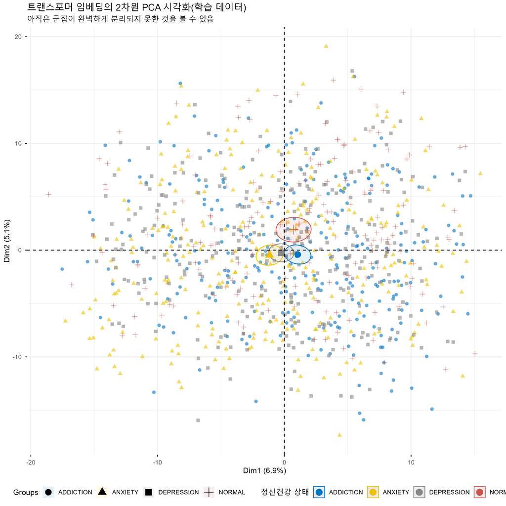

# 8. 효율적인 미세조정(PEFT)과 LoRA 기법

- 앞서 우리는 사전학습된 모델을 **임베딩 추출기**로만 사용했음.
- 하지만 모델 전체를 우리의 데이터(심리상담 텍스트)에 맞춰 추가로 학습시키는 **미세조정(fine-tuning)**을 수행하면 훨씬 더 높은 성능을 얻을 수 있음.

## (1) 트랜스포머 모델 미세조정이란?

- 개념: 이미 대량의 데이터로 사전학습(pre-training)된 거대한 트랜스포머 모델([EX] BERT, RoBERTa)의 파라미터 전체를, 우리가 보유한 특정 도메인 데이터([EX] 심리상담 텍스트)와 특정 작업([EX] 감정분류)에 맞춰 **추가적으로 살짝 더 학습**시키는 과정임.
- 비유
  - 사전학습: ’언어능력 시험 만점자’가 되기 위해 세상의 온갖 책을 다 읽고 일반적인 언어이해 능력을 갖추는 과정.
  - 미세조정: 이 ’언어천재’에게 ’심리상담 전문가’가 되기 위한 전공서적을 추가로 공부시키고, 실제 상담사례를 보여주며 훈련시키는 과정.
  - 효과: 모델이 일반적인 언어지식뿐만 아니라, 우리 데이터 특유의 맥락과 뉘앙스까지 이해하게 됨으로써 단순 임베딩 활용보다 분류성능이 크게 향상됨.

## (2) 미세조정의 문제점: VRAM 부족

- BERT base 모델(약 1.1억 개 파라미터)을 미세조정하려면 모델 가중치 외에도 기울기, 옵티마이저 상태 등을 저장하기 위해 최소 **16GB 이상의 VRAM**이 필요함.
- 대부분의 개인용 GPU나 일반 연구실 환경(VRAM 4~8GB)에서는 실행조차 불가능함.

## (3) 해결책: PEFT(parameter-efficient fine-tuning)

- 모델의 모든 파라미터를 학습하는 대신, **극히 일부의 파라미터만 학습**하여 VRAM 사용량을 획기적으로 줄이는 기법들의 통칭임.
- 대표적인 기법으로 **LoRA(low-rank adaptation)**가 있음.

## (4) LoRA의 핵심원리

- “거대한 모델을 얼리고(freeze), 작은 샌드위치 패티만 끼워넣어 학습하자!”
- 사전학습된 거대한 가중치 행렬($W$)은 고정한 채, 학습 가능한 작은 저랭크(low-rank) 행렬 두 개($A$, $B$)를 추가하여 이들만 학습시킴.
- 원래 $W$가 업데이트되어야 할 변화량($\Delta W$)을 $B \times A$로 근사하는 방식임.
- 효과: 학습해야 할 파라미터 수가 수천 배 줄어들어, VRAM 4~8GB 환경에서도 BERT급 모델의 미세조정이 가능해짐.

### 1) ’저랭크’라고 부르는 이유

- 행렬수학에서 랭크(rank)는 “그 행렬이 담고 있는 필수정보의 독립적인 차원 수”를 의미함.
- 원래 모델의 가중치는 정보량이 많으니 풀 랭크(full rank: 꽉 찬 정보)에 가까움. [EX] 1,000 x 1,000 크기의 행렬에 필수정보가 촘촘히 들어차 있는 것.
- 하지만 특정 작업([EX] 요약, 번역)을 위해 모델을 미세조정할 때 필요한 ’변화’는 모델 전체 지식에 비하면 아주 단순하고 적은 정보량만 있어도 충분함.
- 그래서 “변화량은 낮은 랭크만으로도 표현 가능하다”는 가설을 세우고, 랭크($r$)를 4, 8, 16 같이 아주 작은 숫자로 설정해버린 것.

### 2) 저랭크 행렬: “요약본 만들기”

- 비유: 거대한 언어 모델(LLM)을 학습시키는 과정을 엄청나게 두꺼운 백과사전($W$)을 수정하는 작업이라고 상상해보자.
- 기존의 파인튜닝(full fine-tuning)
  - 과정: 새로운 지식을 가르치기 위해 백과사전의 모든 페이지를 처음부터 끝까지 다시 쓰고 인쇄함.
  - 단점: 비용과 시간이 엄청나게 소요됨.
- LoRA(저랭크 행렬 사용)
  - 가중치 고정: 백과사전 본문은 건드리지 않고 그대로 둠.
  - 그 대신 수정해야 할 내용만 적은 얇은 포스트잇($\Delta W$)을 책 옆에 붙임.
  - 이때 포스트잇에 내용을 아주 압축해서 핵심만 적는데, 이 ’압축된 핵심정보’가 바로 저랭크임.

### 3) 구체적인 작동원리

- 딥러닝 모델의 가중치($W$)는 수많은 숫자가 들어있는 직사각형 표(행렬)임.
- 가령, 모델의 한 층이 1,000 x 1,000 크기의 행렬이라고 가정해보자.

#### A. 기존 방식

- 이 층을 업데이트하려면 1,000 x 1,000 = 1,000,000개의 숫자를 모두 새로 계산하고 저장해야 함. $\Rightarrow$ 너무 무거움!

#### B. LoRA 방식

- LoRA는 변화량(수정할 내용)을 **두 개의 작은 홀쭉한 행렬(A와 B)의 곱**으로 표현함. 이때 두 행렬 사이의 폭을 **랭크($r$)**라고 부름.
- 랭크($r$)를 4로 설정할 경우
  1. 행렬 A(압축): 1,000 x **4** 크기 $\Rightarrow$ 정보를 4개 요점으로 요약.
  2. 행렬 B(복원): **4** x 1,000 크기 $\Rightarrow$ 요약된 정보를 다시 원래 크기로 펼침.
- 결과: 이 두 행렬을 곱하면($A \times B$) 원래 크기인 1,000 x 1,000짜리 변화량 행렬이 만들어짐. 하지만 우리가 실제로 학습(수정)해야 하는 숫자의 개수는 확 줄어듦.
- 계산: (1,000 x 4) + (4 x 1,000) = 4,000 + 4,000 = 8,000개

#### C. 결과 비교

- 기존 방식: 1,000,000개 파라미터 학습.
- LoRA 방식: 8,000개 파라미터 학습.
- 결과: 파라미터 수가 1/125로 줄어듦! 이것이 바로 저랭크 행렬을 사용하는 이유.

### 4) 요약

- LoRA에서 저랭크 행렬이란?: 거대 모델을 수정할 때 **전체를 다 바꾸지 말고, 수정사항을 아주 작은 두 개의 행렬(A, B)로 압축해서 끼워 넣자**는 아이디어임.
- 여기서 압축된 폭($r$)이 작기 때문에 저랭크라고 부름. $\Rightarrow$ 덕분에 메모리를 아주 적게 쓰면서도 거대 모델을 내 입맛대로 튜닝할 수 있게 됨.

# 9. R 환경에서 LoRA를 활용한 모델 미세조정하기

- **reticulate** 패키지를 통해 파이썬의 **peft** 라이브러리와 Hugging Face의 `Trainer` API를 활용하여 LoRA 기반 미세조정을 수행함.

## (1) 주요 함수

### 1) AutoModelForSequenceClassification$from_pretrained()

- 역할: 문장 분류(classification)를 위한 레이어가 부착된 모델을 로드함.
- 논항: `num_labels`(분류할 클래스 개수), `label2id`, `id2label`(라벨 매핑 정보).

### 2) peft$LoraConfig()

- 역할: LoRA 적용을 위한 설정을 정의함.

#### A. task_type = “SEQ_CLS”(작업 유형)

- 의미: “지금 우리가 하려는 일이 도대체 무엇인가?”를 모델에게 알려주는 것.
- 설명:
  - `SEQ_CLS`는 **Seq**uence **Cl**as**s**ification의 약자. $\Rightarrow$ **문장분류** 작업을 의미.
  - 텍스트(sequence)를 입력했을 때, 이것이 ’우울’인지 ’불안’인지 ’일반’인지 딱 하나의 라벨로 분류(classification)하는 작업을 하겠다고 선언하는 것.
- 비유: “이 훈련은 ‘달리기’ 훈련이 아니라 ‘수영’ 훈련이야”라고 종목을 정해주는 것과 같음. 종목에 따라 훈련방식이나 필요한 장비가 달라지니까!

#### B. r(rank, 랭크 크기)

- 의미: LoRA 어댑터(추가부품)의 용량 또는 크기.
- 설명
  - 우리는 앞서 LoRA는 거대한 원래 모델 옆에 아주 작은 수학행렬 두 개(A, B)를 붙여서 학습한다고 배웠음. `r`은 이 행렬의 **폭**을 결정하는 숫자임.
  - 숫자가 작을 경우: [EX] 4, 8. 학습할 파라미터 수가 적어서 매우 빠르고 메모리를 적게 씀. 하지만 복잡한 패턴을 배우는 데는 한계가 있을 수 있음.
  - 숫자가 클 경우: [EX] 32, 64). 더 많은 정보를 담을 수 있어 성능이 좋아질 수 있지만, 메모리를 더 많이 쓰고 학습이 느려짐.
- 비유: 수업내용을 필기할 메모장의 크기와 같음.
  - `"r = 4"`: 작은 포스트잇. 핵심만 딱 적어서 가볍지만, 많은 내용은 못 적음.
  - `"r = 64"`: 큰 A4 공책. 자세한 내용을 다 적을 수 있지만, 들고 다니기 무거움.
  - 참고: 보통 4, 8, 16 정도만 써도 충분한 성능을 냄.

#### C. LoRA 어댑터

##### 가. 비유: 거대한 백과사전 수정하기

- LLM을 “전 세계 모든 지식이 담긴 수천 페이지짜리 백과사전”이라고 상상해보자.
- 문제점: 이 백과사전에 ’최신 유행어’나 ’우리 회사의 전문 용어’를 추가하고 싶음. 그런데 백과사전을 처음부터 끝까지 다시 인쇄하려면(fine-tuning) 종이도 많이 들고(메모리), 시간도 너무 오래 걸림.
- LoRA의 해결책: 백과사전 본문은 그대로 두고(freeze), 책 옆에 얇은 포스트잇(LoRA 어댑터)을 붙이는 것.
  - 이 포스트잇에는 수정하거나 추가하고 싶은 내용만 핵심적으로 적음.
  - 나중에 책을 읽을 때(inference), 본문 내용과 포스트잇 내용을 함께 읽으면 업데이트된 지식을 알 수 있음.

##### 나. 기술적 설명: 저랭크 행렬의 마법

- LoRA는 “거대 모델의 가중치($W$) 행렬을 직접 건드리지 않고, 변화량($\Delta W$)만 따로 학습하자”는 아이디어.
- 기존 모델 ($W$): 100억 개의 숫자로 이루어진 거대한 행렬. 이걸 학습하려면 엄청난 GPU 메모리가 필요.
- LoRA 어댑터($A \times B$): 변화량을 표현하는 아주 작은 행렬 두 개.
  - 원래는 100억 개의 숫자를 바꿔야 한다면, LoRA는 그 1%도 안 되는 숫자만 바꿔서 비슷한 효과를 냄.
  - 이 작은 행렬들이 바로 **어댑터**임. 마치 전기 플러그 어댑터처럼, 거대 모델에 톡 끼워서 사용하는 것.

##### 다. 왜 쓰는가?(장점)

1. 가볍다: 전체 모델을 저장할 필요 없이, 몇십 MB짜리 어댑터 파일만 저장하면 됨(원본 모델은 그대로 둠).
2. 빠르다: 학습해야 할 숫자가 적으니 학습 속도가 훨씬 빠름.
3. 갈아끼우기 쉽다:
   - ’한국어 어댑터’를 끼우면 한국어를 잘하게 됨.
   - ’코딩 어댑터’를 끼우면 코딩을 잘하게 됨.
   - 원본 모델 하나에 여러 어댑터를 바꿔 끼우며 다양한 용도로 쓸 수 있음.
4. 요약
   - LoRA 어댑터는 거대 모델을 통째로 재수술하는 대신, “작고 가벼운 추가 부품(포스트잇)만 따로 만들어서 붙이는 기술”임.
   - 덕분에 일반적인 컴퓨터에서도 거대 모델을 나만의 맞춤형 모델로 튜닝할 수 있게 해줌.

#### D. lora_alpha(스케일링 계수)

- 의미: LoRA가 학습한 내용을 원래 모델에 얼마나 강하게 반영할지를 조절하는 강도.
- 설명
  - 학습된 LoRA 값에 $\frac{\alpha}{r}$만큼 곱해서 원래 모델에 더해줌.
  - 이 값이 크면 LoRA가 학습한 새로운 지식을 더 적극적이고 강하게 반영함.
  - 이 값이 작으면 원래 모델이 가지고 있던 지식을 더 존중하고, 새로운 변화는 조심스럽게 받아들임.
- 비유: 요리할 때 넣는 ’소금의 양’이나 ’간 맞추기’와 비슷함.
  - `r`이 재료의 양이라면, `lora_alpha`는 그 재료의 맛을 얼마나 진하게 낼지 결정.
  - 참고: 보통 `r`과 같은 값이나, `r`의 2배 정도로 설정하는 것이 일반적.

#### E. lora_dropout(드롭아웃 비율)

- 의미: 과적합(overfitting)을 막기 위해 학습 중에 일부러 정보를 조금 삭제하는 비율.
- 설명
  - 0.1(10%)로 설정하면, 학습할 때 LoRA 행렬의 데이터 중 10%를 무작위로 0으로 만들어버림.
  - 이렇게 하면 모델이 특정 데이터나 패턴에만 집착(암기)하지 않고, 좀 더 유연하고 일반적인 능력을 갖게 됨.
- 비유
  - 시험공부를 할 때, ’일부러 구멍 뚫린 문제집’으로 공부하는 것과 같음.
  - 모든 글자가 다 보이는 책으로만 공부하면 그 문장 자체를 외워버릴 수 있지만(과적합), 중간중간 지워진 부분이 있으면 문맥을 파악하는 ’진짜 실력’을 키울 수 있음.

**[표 3] `peft$LoraConfig()`의 주요 논항**

| 논항 | 이름 | 의미 | 비유 |
| --- | --- | --- | --- |
| `task_type` | 작업 유형 | “우리는 **문장분류(`SEQ_CLS`)**를 할 거야.” | 운동종목 정하기(축구? 농구?) |
| `r` | 랭크 | “추가할 두뇌(부품)의 **용량**은 8만큼이야.” | 메모장의 크기(포스트잇 vs. 공책) |
| `lora_alpha` | 스케일링 | “새로 배운 내용을 **얼마나 강하게** 적용할까?” | 요리의 간 맞추기(싱겁게 vs. 짜게) |
| `lora_dropout` | 드롭아웃 | “너무 달달 외우지 않게 **10%는 가리고** 학습해.” | 구멍 뚫린 문제집 풀기 |

### 3) peft$get_peft_model()

- 기본 모델에 LoRA 설정을 적용하여, 학습 가능한 파라미터가 축소된 PEFT 모델로 변환함.

### 4) Trainer()

#### A. 이론적 설명

- 역할: Hugging Face에서 제공하는 모델 학습 관리자. 학습 루프, 평가, 저장 등을 자동으로 처리함.
- 논항
  - `model`
    - 설명: 학습시킬 Hugging Face 트랜스포머 모델 객체임.
    - 의미: 여기에는 단순히 사전학습된 모델(`AutoModelForSequenceClassification`)을 넣을 수도 있지만, 이번 실습에서는 **LoRA 설정이 적용된 `model_lora` 객체**를 전달함. 이렇게 하면 `Trainer()`는 전체 파라미터가 아닌, LoRA 어댑터 부분만 학습하게 되어 VRAM을 절약할 수 있음.
  - `args`(학습 파라미터)
    - 설명: `TrainingArguments` 객체를 통해 정의된 **학습 관련 모든 설정값**들의 집합.
    - 의미: 학습률(`learning_rate`), 배치 크기(`per_device_train_batch_size`), 에포크 수(`num_train_epochs`), 저장경로(`output_dir`), 평가전략(`eval_strategy`) 등 모델이 **어떻게 학습될지를 결정하는 핵심규칙**들이 담겨 있음. `Trainer()`는 이 규칙에 따라 학습 루프를 돌게 됨.
  - `TrainingArguments`
    - 설명
      - `Trainer()`가 ’선생님’이라면, `TrainingArguments`는 그 선생님이 들고 있는 수업 계획서 또는 학습 지침서에 해당.
      - `TrainingArguments`는 Hugging Face의 **transformers** 라이브러리에서 모델을 학습시킬 때 필요한 모든 하이퍼파라미터(설정값)를 담고 있는 객체(꾸러미)임.
    - 필요성
      - 모델(`model`): 공부해야 할 학생(백지상태 or 어느 정도 아는 상태).
      - 데이터셋(`train_dataset`): 공부할 교과서.
      - Trainer(`trainer`): 옆에서 공부를 시키는 과외 선생님.
      - TrainingArguments(`args`): 선생님이 짠 “학습 계획표”
        - 배치 크기: 하루에 몇 페이지씩 볼래?
        - 에포크: 책을 몇 번 반복해서 볼래?
        - 평가 주기: 시험은 며칠에 한 번 볼래?
        - 학습률: 진도는 얼마나 빨리 나갈까?
      - 이 ’학습 계획표’가 없으면 선생님(`Trainer`)은 학생(`model`)을 얼마나 어떻게 가르쳐야 할지 알 수 없음.
    - 요약:`TrainingArguments`는 “VRAM 용량은 작고, 데이터는 많으니, 이렇게 쪼개서 저런 속도로 공부하고, 중간중간 시험 봐서 제일 잘한 걸 남겨라”라고 `Trainer()`에게 알려주는 상세 지시서임.
  - `train_dataset`
    - 설명: 모델 학습에 사용할 훈련 데이터셋.
    - 구체적 의미
      - `datasets.Dataset` 형식이어야 하며, 내부에는 모델이 이해할 수 있는 `input_ids`(토큰 ID), `attention_mask`(어텐션 마스크), `label`(정답 라벨) 등의 정보가 사전 형태로 포함되어 있음.
      - `Trainer()`는 이 데이터를 배치 단위로 꺼내어 모델에 주입하고 가중치를 업데이트함.
  - `eval_dataset`
    - 설명: 학습 중간이나 종료 후에 모델의 성능을 평가할 검증(테스트) 데이터셋.
    - 구체적 의미
      - `train_dataset`과 동일한 형식을 갖지만, 모델 학습(가중치 업데이트)에는 절대 사용되지 않음. 오직 모델이 학습하지 않은 새로운 데이터에 대해 얼마나 잘 맞추는지(일반화 성능)를 확인하는 용도로 쓰임.
      - `args`에서 설정한 `eval_strategy`에 따라 주기적으로 이 데이터를 사용해 평가를 수행함.

**[표 4] `TrainingArguments`에 포함된 주요 논항**

| 논항 | 의미(직관적 설명) | 구체적 역할 |
| --- | --- | --- |
| `output_dir` | 성적표 및 결과 저장소 | 학습 중간중간 저장되는 모델(체크포인트)과 최종 결과를 저장할 폴더 경로. |
| `num_train_epochs` | N회독(반복 횟수) | 전체 데이터셋(문제집 1권)을 처음부터 끝까지 몇 번 반복해서 공부할 것인지 설정([EX] 3회독). |
| `per_device_train_batch_size` | 한 입 크기 | 한 번에 GPU 메모리에 올려서 처리할 데이터의 개수. VRAM이 작으면 이 숫자를 줄여야 함([EX] 4개씩 공부). |
| `gradient_accumulation_steps` | 몰아서 정리하기 | (저사양 GPU 필수) 배치를 작게(4개) 공부하지만, 바로 업데이트하지 않고 기다렸다가 여러 번(4번) 모아서 한 번에(4*4=16개 효과) 가중치를 수정하는 기법. |
| `learning_rate` | 공부속도 | 한 번 학습할 때 지식을 얼마나 많이 받아들일지 결정. 너무 크면 대충 배워서 틀리고, 너무 작으면 배우는 데 천년만년 걸림(LoRA는 보통 2e-4 사용). |
| `weight_decay` | 암기금지(응용력) | 모델이 정답을 달달 외우는 것(과적합)을 방지하기 위해 가중치에 패널티를 주는 규제(regularization) 값. |
| `eval_strategy` | 모의고사 날짜 | 언제 테스트 데이터로 평가할지 결정. `"epoch"`는 1회독이 끝날 때마다, `"steps"`는 특정 스텝마다 평가. |
| `save_strategy` | 세이브 포인트 | 언제 모델을 저장할지 결정. 보통 평가(`eval_strategy`)와 주기를 맞춤. |
| `load_best_model_at_end` | 최고 점수 기억 | 학습이 다 끝난 후, 가장 성적이 좋았던 시점의 모델을 자동으로 불러옴(이게 `TRUE`여야 안심할 수 있음). |

#### B. 실습용 예시

- 실제 코드에서는 아래와 같이 `transformers$TrainingArguments` 함수 안에 이 내용들을 묶어서 전달함.

```r
# 학습 계획표 저장 경로 생성
dir.create("DL_results", recursive = T)
output_dir <- "DL_results"

# 학습 계획표 작성
training_args <- transformers$TrainingArguments(

  # 1. 저장위치
  output_dir = output_dir,

  # 2. 학습 분량 및 속도
  num_train_epochs = 3L, # 책 3번 정독하세요.
  per_device_train_batch_size = 4L, # 한 번에 4문제씩만 보세요(VRAM 절약).
  gradient_accumulation_steps = 4L, # 하지만 4번 모아서(4*4=16문제 본 효과) 머리에 입력하세요.
  learning_rate = 2e-4, # 지식습득 속도는 0.0002입니다.

  # 3. 평가 및 저장 규칙
  eval_strategy = "epoch", # 책 1번 다 볼 때마다 모의고사 치르세요.
  save_strategy = "epoch", # 모의고사 치를 때마다 저장(세이브) 하세요.
  load_best_model_at_end = TRUE, # 다 끝나면 제일 잘 본 시험지 기준으로 모델을 되돌리세요.

  # 4. 기타 설정
  fp16 = TRUE, # (옵션) 계산할 때 소수점 자릿수를 줄여서 속도를 높이세요(반정밀도).
  remove_unused_columns = FALSE # 데이터셋에 쓸데없는 열이 있어도 지우지 말고 그냥 두세요.
  )
```

## (2) 모델 및 토크나이저 준비(분류용)

- 임베딩 추출용 모델(`AutoModel`)이 아니라, 분류 레이어가 부착된 분류용 모델(`AutoModelForSequenceClassification`)을 로드해야 함.

```r
# -----------------------------------------------------------------------------
# 1. 라벨 정보와 ID 매핑 준비
# -----------------------------------------------------------------------------
# 데이터에 있는 고유한 라벨들(우울, 불안, 중독 등)을 추출함.
labels_vec <- levels(df_full$label)

# 라벨의 총 개수를 셈.
num_labels <- length(labels_vec)

# 라벨 문자열을 0부터 시작하는 정수 ID로 매핑하는 리스트를 만듦([EX] 우울 -> 0).
# setNames로 이름을 부여하고 as.list로 리스트로 변환함.
label2id <- as.list(setNames(0:(num_labels-1), labels_vec))

# 반대로 정수 ID를 라벨 문자열로 매핑하는 리스트를 만듦([EX] 0 -> 우울).
id2label <- as.list(setNames(labels_vec, 0:(num_labels-1)))

# -----------------------------------------------------------------------------
# 2. 분류용 사전학습 모델 로드
# -----------------------------------------------------------------------------
model_name <- "klue/roberta-base"

# AutoModelForSequenceClassification$from_pretrained(): 문장 분류를 위한 레이어가 추가된 모델을 로드함.
# 이때 라벨 개수(num_labels)와 매핑 정보(label2id, id2label)를 함께 전달하여 모델의 출력층을 초기화함.
model_clf <- transformers$AutoModelForSequenceClassification$from_pretrained(
  model_name,
  num_labels = num_labels,
  label2id = label2id,
  id2label = id2label
  )

# 토크나이저는 앞서 사용한 것과 동일한 것을 로드함.
tokenizer_clf <- transformers$AutoTokenizer$from_pretrained(model_name)
```

## (3) LoRA 설정 및 적용(PEFT 활용)

- **peft** 라이브러리를 사용하여 로드한 분류 모델에 LoRA 어댑터를 부착함. 이 과정에서 기존 모델의 파라미터는 자동으로 고정(freeze)됨.

```r
# -----------------------------------------------------------------------------
# 1. LoRA 하이퍼파라미터 설정 (LoraConfig)
# -----------------------------------------------------------------------------
# peft$LoraConfig(): LoRA 적용을 위한 설정객체를 생성함.
peft_config <- peft$LoraConfig(
  # task_type: 현재 수행하려는 작업유형을 지정함. 문장 분류는 SEQ_CLS(sequence classification)임.
  task_type = peft$TaskType$SEQ_CLS,
  # r: LoRA의 핵심인 저랭크 행렬의 차원(rank)임.
  # 값이 클수록 학습할 파라미터가 많아지고 표현력이 커지지만 VRAM을 더 소요함. 보통 4, 8, 16을 많이 사용.
  r = 8L,
  # lora_alpha: 스케일링 계수임. 학습 안정성을 위해 사용하며, 보통 r 값과 같거나 2배 정도로 설정함.
  lora_alpha = 16L,
  # lora_dropout: 과적합 방지를 위한 드롭아웃 비율.
  lora_dropout = 0.1
)

# -----------------------------------------------------------------------------
# 2. 기본 모델에 LoRA 어댑터 장착
# -----------------------------------------------------------------------------
# peft$get_peft_model(): 불러온 기본 분류 모델(model_clf)에 위에서 정의한 LoRA 설정(peft_config)을 적용함.
# 이 함수가 실행되면 기존 모델의 파라미터는 모두 고정(freeze)되고, 새로 추가된 작은 LoRA 행렬들만 학습 가능한 상태가 됨.
model_lora <- peft$get_peft_model(model_clf, peft_config)

# -----------------------------------------------------------------------------
# 3. 학습 가능한 파라미터 수 확인
# -----------------------------------------------------------------------------
# print_trainable_parameters(): 전체 파이미터 중 실제로 학습되는 파라미터가 몇 개인지, 비율은 얼마나 되는지 출력함.
# LoRA가 정상적으로 적용되었다면 이 비율이 1% 미만으로 매우 작게 나와야 함.
model_lora$print_trainable_parameters()
```

## (4) 데이터셋 준비(Hugging Face Dataset 형식 변환)

- Hugging Face의 `Trainer`를 사용하려면 데이터를 `datasets.Dataset` 객체로 변환해야 함.
- R 데이터프레임을 파이썬 딕셔너리 리스트로 변환 후, 파이썬 측에서 `Dataset`으로 만듦.

### 1) 라벨 인덱스 보정하기

```r
# ------------------------------------------------------------------------------
# [사전작업] 라벨 인덱스 보정(R -> 파이썬)
# ------------------------------------------------------------------------------
# R은 숫자를 셀 때 1부터 세지만(1, 2, 3...), 파이썬은 0부터 셈(0, 1, 2...).
# 따라서 팩터(factor)를 정수로 바꾼 뒤 1을 빼줘야 에러가 나지 않음.

df_train$label <- as.integer(as.factor(df_train$label)) - 1L
df_test$label <- as.integer(as.factor(df_test$label)) - 1L

# (확인) 결과가 0, 1, 2, 3으로 나오는지 눈으로 확인
unique(as.integer(as.factor(df_train$label)) - 1L)
```

### 2) 형태 변환하기

```r
# ==============================================================================
# 함수 이름: df_to_dict_list()
# 기능: R의 데이터프레임을 파이썬 리스트(list of dicts)로 변환함.
# ==============================================================================
df_to_dict_list <- function(df) {

  # ----------------------------------------------------------------------------
  # 1. tidyverse(purrr) 패키지의 transpose() 함수 활용
  # ----------------------------------------------------------------------------
  # 이 함수 한 줄이 복잡한 for loop(반복문)를 대체함.
  #
  # [변환 전: R 데이터프레임 (열 중심)]
  #  - text 열:  ("안녕", "반가워", "잘가")
  #  - label 열: (   0,          1,           0  )
  #
  # [변환 후: Python 리스트 (행 중심)]
  #  - 리스트 1번: list(text="안녕", label=0)
  #  - 리스트 2번: list(text="반가워", label=1)
  #  - 리스트 3번: list(text="잘가", label=0)
  # ----------------------------------------------------------------------------

  result_list <- transpose(df)

  # ----------------------------------------------------------------------------
  # 2. 결과 반환
  # ----------------------------------------------------------------------------
  # 변환된 리스트를 반환함.
  # 이 결과물은 나중에 datasets$Dataset$from_list() 함수에 들어가게 됨.
  return(result_list)
}
```

### 3) 토크나이저 함수 만들기

- 기능: 모델에게 “내담자의 말을 128 토큰까지 들어줘”라고 요청하는 것.

```r
# ==============================================================================
# 함수 이름: tokenize_function
# 기능: 텍스트를 토크나이저에 넣어 '정수 인덱스'로 변환하고 길이를 맞춤.
# 특징: Hugging Face의 map() 함수에 의해 데이터셋 전체에 적용될 예정임.
# ==============================================================================
tokenize_function <- function(examples) {

  # 1. 토크나이저 호출(tokenizer_clf는 이미 로드된 객체)
  # examples[['text']]: 데이터셋에서 'text' 열(내담자의 발화 내용)만 뽑아서 입력함.
  return(tokenizer_clf(
    examples[['text']],

    # 2. 패딩(padding): "짧은 문장은 0으로 채워라"
    # - max_length(512)보다 짧은 문장은 남는 공간을 0(PAD 토큰)으로 채워서
    # - 모든 문장의 길이를 똑같이 맞춤(행렬연산을 위해 필수).
    padding = "max_length",

    # 3. 자르기(truncation): "너무 긴 문장은 잘라라"
    # - max_length(128)보다 긴 문장이 들어오면 뒷부분을 자름.
    # - 이걸 TRUE로 안 하면 에러가 남.
    truncation = TRUE,

    # 4. 짧은 길이 설정(수업시간의 한계 상): "128 토큰까지는 들어라"
    # - 기존에 주로 사용되던 128L 사용(최대 512L까지 가능).
    # - 모델은 내담자의 발화의 앞부분 정도까지만 들을 수 있음(본론[핵심호소]까지 읽으려면 최대 토큰 수를 늘려야 함)
    # - 숫자 뒤 'L'은 "이건 소수점 없는 정수야!"라고 R에게 알려주는 표시임.
    max_length = 128L
  ))
}
```

### 4) 연결하기

- 이제 `df_to_dict_list()` 함수를 사용하여 데이터셋을 만들고, `tokenize_function()`(128길이 설정)을 적용하면 됨.

```r
# 1. R 데이터프레임을 리스트로 변환
train_list <- df_to_dict_list(df_train) # as.integer(as.factor(df_train$label)) - 1L 처리를 마친 df_train 데이터프레임을 인자로 넣어야 함.
test_list <- df_to_dict_list(df_test) # as.integer(as.factor(df_test$label)) - 1L 처리를 마친 df_test 데이터프레임을 인자로 넣어야 함.

# 2. Hugging Face 데이터셋 객체 생성
# datasets 라이브러리: Hugging Face에서 효율적인 데이터 처리를 위해 제공하는 라이브러리임.
datasets <- import("datasets")
train_dataset_raw <- datasets$Dataset$from_list(train_list)
test_dataset_raw <- datasets$Dataset$from_list(test_list)

# 3. 원본 데이터셋의 모든 열 이름을 가져옴
all_cols <- train_dataset_raw$column_names

# 4. 절대로 지우면 안 되는 열 이름 지정(정답 라벨!)
keep_cols <- c("label")

# 5. 지워야 할 열 목록 계산
# (전체 열) - (지킬 열) = (지워야 할 열)
# setdiff() 함수가 이 차집합 계산을 해줌.
cols_to_remove <- setdiff(all_cols, keep_cols)

# (확인) 지워질 목록에 'label'이 없는지 꼭 확인!
cols_to_remove

# 6. 토크나이징 적용(map() 함수 사용)
# - 여기서 비로소 텍스트가 숫자로 바뀌고, 길이(128)가 맞춰짐.
# - input_ids, attention_mask, label 열 빼고는 다 지워야 함.
train_dataset <- train_dataset_raw$map(
  tokenize_function,
  batched = TRUE,
  remove_columns = cols_to_remove
)

test_dataset <- test_dataset_raw$map(
  tokenize_function,
  batched = TRUE,
  remove_columns = cols_to_remove
)

train_dataset$column_names
# 정상 결과: "label", "input_ids", "attention_mask", "token_type_ids" 가 보여야 함.
```

## (4) 학습 설정 및 trainer 실행

### 1) 학습 설정 및 모델 학습

- `TrainingArguments()`로 학습 파라미터를 설정하고, `trainer` 객체를 생성하여 학습을 시작함.
- 저용량 VRAM 환경을 위해 배치 크기를 줄이고 기울기 누적(기울기를 몇 개씩 모았다가 한 번에 가중치를 업데이트)을 사용함.

```r
# 학습된 모델과 체크포인트가 저장될 경로를 지정함.
output_dir <- "lora_finetuned_model"
dir.create("lora_finetuned_model", recursive = T)

# -----------------------------------------------------------------------------
# 1. 학습 파라미터 설정(TrainingArguments)
# -----------------------------------------------------------------------------
# transformers$TrainingArguments: 학습에 필요한 모든 세부 설정을 담는 객체임.
training_args <- transformers$TrainingArguments(
  output_dir = output_dir, # 결과저장 경로
  learning_rate = 2e-4, # 학습률: LoRA는 일반 미세조정(보통 2e-5)보다 약간 높게 잡는 것이 좋음.

  # --- 저용량 VRAM을 위한 핵심설정 ---
  # per_device_train_batch_size: 한 번에 GPU에 올릴 실제 배치 크기임. VRAM이 작으면 이 값을 줄여야 함([EX] 4, 8).
  per_device_train_batch_size = 4L,
  # gradient_accumulation_steps: 기울기(그래디언트)를 몇 개씩 모아서 가중치를 한 번에 업데이트할지 설정함.
  # 실제 학습효과는 (per_device_train_batch_size * gradient_accumulation_steps) 크기의 배치를 쓴 것과 같아짐.
  # 여기서는 4 * 4 = 16의 배치 크기 효과를 냄. 작은 VRAM으로 큰 배치 학습효과를 내는 핵심기법임.
  gradient_accumulation_steps = 4L,
  # ----------------------------------

  num_train_epochs = 3L, # 전체 데이터를 몇 번 반복해서 학습할지 설정함(에포크 수).
  weight_decay = 0.01, # 가중치 감쇠: 과적합을 막기 위한 규제(regularization) 파라미터임.
  eval_strategy = "epoch", # 평가 주기: 매 에포크가 끝날 때마다 테스트 데이터로 성능을 평가함.
  save_strategy = "epoch", # 저장 주기: 매 에포크가 끝날 때마다 모델 체크포인트를 저장함.
  load_best_model_at_end = TRUE, # 학습종료 후 가장 성능이 좋았던 때의 모델을 자동으로 불러옴.
  push_to_hub = FALSE, # Hugging Face Hub에 모델을 업로드하지 않음.
  remove_unused_columns = FALSE, # 중요: R에서 만든 커스텀 데이터셋을 사용할 때 이 옵션을 FALSE로 해야 오류가 안 남.
  # use_cpu: GPU 사용 여부를 결정함. GPU가 있으면 FALSE, 없으면 TRUE로 자동 설정함.
  use_cpu = ifelse(torch$cuda$is_available(), FALSE, TRUE)
)

# -----------------------------------------------------------------------------
# 2. trainer 객체 생성
# -----------------------------------------------------------------------------
# transformers$Trainer: 실제 학습 과정을 관리하고 실행하는 엔진 역할을 하는 객체임.
trainer <- transformers$Trainer(
  model = model_lora, # 학습할 모델(LoRA가 적용된 모델)
  args = training_args, # 위에서 정의한 학습 파라미터
  train_dataset = train_dataset, # 학습용 데이터셋
  eval_dataset = test_dataset, # 평가용 데이터셋
  tokenizer = tokenizer_clf, # 토크나이저
  # data_collator: 배치 내의 문장 길이를 가장 긴 문장에 맞춰 동적으로 패딩해주는 역할을 함. 효율적인 학습을 위해 필요함.
  data_collator = transformers$DataCollatorWithPadding(tokenizer = tokenizer_clf)
)

# -----------------------------------------------------------------------------
# 3. 학습 시작
# -----------------------------------------------------------------------------
# trainer$train(): 실제 학습 루프를 실행함.
# 주의: 데이터 크기와 하드웨어 성능에 따라 시간이 매우 오래 걸릴 수 있음.
# 수업시간에는 실행시간을 고려하여 이 코드를 실행하지 않고 넘어갈 수도 있음(약 1시간 10분 소요).
set.seed(123) # 재현 가능성을 위해 난수 고정하기.
trainer$train()

# -----------------------------------------------------------------------------
# 4. 모델 저장
# -----------------------------------------------------------------------------
# 학습된 LoRA 어댑터 가중치만 별도로 저장함. 용량이 매우 작음.
trainer$save_model(output_dir)

# 토크나이저 저장(필수! 이거 없으면 나중에 글자를 숫자로 못 바꿈)
tokenizer_clf$save_pretrained(output_dir)
```

### 2) 저장한 모델 로드하기

- 전제: 새로운 R 세션에서 이전 세션에 저장해둔 모델을 로드하거나, 다른 사람이 생성한 모델을 로드할 경우에 한함. 학습 후 같은 세션에서 바로 평가단계로 들어갈 경우, 이번 모델 로드 단계는 생략할 것.
- 유의사항: LoRA 모델은 절대 혼자서 작동하지 않음. $\Rightarrow$ 원본 모델(klue-BERT) 을 먼저 부르고, 그 위에 저장된 LoRA 가중치를 덧씌워야 함.
- 비유: LoRA 모델은 기생충 같은 존재라서 숙주인 원본 모델이 없으면 살 수 없음! 그래서 원본 모델을 먼저 부르고 $\rightarrow$ LoRA를 입히는 두 단계가 필요함.

```r
# ------------------------------------------------------------------------------
# 1. 필요한 파이썬 라이브러리 다시 로드
# ------------------------------------------------------------------------------
transformers <- import("transformers")
peft <- import("peft")
torch <- import("torch")

# LoRA 모델 압축 파일 URL
lora_url <- "https://raw.githubusercontent.com/cognitivepsychology/NLP_2025/main/data/lora_finetuned_model.zip"
# 로컬에 저장할 파일명
lora_file <- "lora_finetuned_model/lora_finetuned_model.zip"
# LoRA 모델 압축 파일 다운로드하기
download.file(lora_url, lora_file)
# LoRA 모델 압축 파일 풀기
unzip(lora_file, exdir = "lora_finetuned_model")

# ------------------------------------------------------------------------------
# 2. 경로설정(아까 저장했던 그 폴더)
# ------------------------------------------------------------------------------
model_path <- "lora_finetuned_model"

# ------------------------------------------------------------------------------
# 3. 토크나이저 로드(단어장 불러오기)
# ------------------------------------------------------------------------------
tokenizer_clf <- transformers$AutoTokenizer$from_pretrained(model_path)

# ------------------------------------------------------------------------------
# 4. [중요] 모델 로드(2단계 합체 과정)
# ------------------------------------------------------------------------------

# 단계 A: '원본' 깡통 모델(base model)을 먼저 로드함
# (우리가 학습시킨 게 아니라, Hugging Face에 있는 깨끗한 원본임)
base_model <- transformers$AutoModelForSequenceClassification$from_pretrained(
  "klue/bert-base",
  num_labels = 4L
)

# 단계 B: 우리가 저장한 'LoRA 가중치'를 원본에 장착함
# PeftModel$from_pretrained(원본 모델, 저장된 경로)
model_lora <- peft$PeftModel$from_pretrained(base_model, model_path)

## Plan-B: 단계 B에서 오류가 발생하는 경우 ##

# 깡통 모델을 따로 부르지 않고, '완성품'을 한 번에 부르기.
model_lora <- peft$AutoPeftModelForSequenceClassification$from_pretrained(
  model_path,
  num_labels = 4L  # 라벨 개수 명시
)

# 학습용 데이터셋 URL
train_dataset_url <- "https://raw.githubusercontent.com/cognitivepsychology/NLP_2025/main/data/train_dataset.rda"
# 로컬에 저장할 파일명
train_dataset_file <- "train_dataset.rda"
# 학습용 데이터셋 파일 다운로드하기
download.file(train_dataset_url, train_dataset_file)

# 학습용 데이터셋 URL
test_dataset_url <- "https://raw.githubusercontent.com/cognitivepsychology/NLP_2025/main/data/test_dataset.rda"
# 로컬에 저장할 파일명
test_dataset_file <- "test_dataset.rda"
# 학습용 데이터셋 파일 다운로드하기
download.file(test_dataset_url, test_dataset_file)

# 학습용 & 테스트용 데이터셋 로드하기
load("train_dataset.rda")
load("test_dataset.rda")

# 학습 파라미터 설정
training_args <- transformers$TrainingArguments(
  output_dir = output_dir, # 결과저장 경로
  learning_rate = 2e-4, # 학습률: LoRA는 일반 미세조정(보통 2e-5)보다 약간 높게 잡는 것이 좋음.

  # --- 저용량 VRAM을 위한 핵심설정 ---
  # per_device_train_batch_size: 한 번에 GPU에 올릴 실제 배치 크기임. VRAM이 작으면 이 값을 줄여야 함([EX] 4, 8).
  per_device_train_batch_size = 4L,
  # gradient_accumulation_steps: 그래디언트를 몇 번 모아서 가중치를 업데이트할지 설정함.
  # 실제 학습효과는 (per_device_train_batch_size * gradient_accumulation_steps) 크기의 배치를 쓴 것과 같아짐.
  # 여기서는 4 * 4 = 16의 배치 크기 효과를 냄. 작은 VRAM으로 큰 배치 학습효과를 내는 핵심기법임.
  gradient_accumulation_steps = 4L,
  # ----------------------------------

  num_train_epochs = 3L, # 전체 데이터를 몇 번 반복해서 학습할지 설정함(에포크 수).
  weight_decay = 0.01, # 가중치 감쇠: 과적합을 막기 위한 규제(regularization) 파라미터임.
  eval_strategy = "epoch", # 평가 주기: 매 에포크가 끝날 때마다 테스트 데이터로 성능을 평가함.
  save_strategy = "epoch", # 저장 주기: 매 에포크가 끝날 때마다 모델 체크포인트를 저장함.
  load_best_model_at_end = TRUE, # 학습종료 후 가장 성능이 좋았던 때의 모델을 자동으로 불러옴.
  push_to_hub = FALSE, # Hugging Face Hub에 모델을 업로드하지 않음.
  remove_unused_columns = FALSE, # 중요: R에서 만든 커스텀 데이터셋을 사용할 때 이 옵션을 FALSE로 해야 오류가 안 남.
  # use_cpu: GPU 사용 여부를 결정함. GPU가 있으면 FALSE, 없으면 TRUE로 자동 설정함.
  use_cpu = ifelse(torch$cuda$is_available(), FALSE, TRUE)
)

# trainer 객체 생성
trainer <- transformers$Trainer(
  model = model_lora, # 학습할 모델(LoRA가 적용된 모델)
  args = training_args, # 위에서 정의한 학습 파라미터
  train_dataset = train_dataset, # 학습용 데이터셋
  eval_dataset = test_dataset, # 평가용 데이터셋
  # data_collator: 배치 내의 문장 길이를 가장 긴 문장에 맞춰 동적으로 패딩해주는 역할을 함. 효율적인 학습을 위해 필요함.
  data_collator = transformers$DataCollatorWithPadding(tokenizer = tokenizer_clf)
)

# (선택) 모델을 평가 모드(eval)로 전환(학습 안 할 거니까)
model_lora$eval() # 만약 에러 나면 생략 가능(PyTorch 객체일 때만 작동)
cat("모델 로딩 완료! 이제 예측을 시작할 수 있습니다.\n")
```

## (5) 학습된 모델 평가

### 1) 오차 평가

- 성능평가
  - 학습이 완료된 후, 테스트 데이터셋을 이용하여 모델의 성능을 평가함.
  - `loss`가 0에 가까울수록 좋은 성능을 나타냄.
- `eval_loss`
  - 의미: 모델의 예측이 정답 확률 분포에서 얼마나 벗어났는지를 나타내는 ‘벌점(penalty)’ 임(cross-entropy loss).
  - 해석: 0에 가까울수록 좋음.
  - 심층분석: 우리가 분류해야 할 주제가 4개(중독, 불안, 우울, 일반)임. 만약 모델이 아무것도 모르고 무작위로 찍는다면(확률 25%), 손실값은 약 1.386($-\ln(0.25)$)이 나옴.
  - 결론: 현재 수치는 무작위 찍기(1.38)보다 조금 나은 수준임. $\Rightarrow$ 모델이 아직 제대로 학습되지 않았거나, 학습이 충분치 않음을 시사함.
- `eval_runtime`: 평가(시험)를 치르는 데 걸린 시간이 약 35초라는 뜻임. 성능과는 무관한 속도 지표임.
- `epoch`(3): 전체 데이터셋을 세 바퀴 돌며 학습했다는 뜻임.

```r
# -----------------------------------------------------------------------------
# 학습 결과 평가(벌점표[틀린 정도만 표시]만 제시)
# -----------------------------------------------------------------------------
cat("모델 평가 시작...\n")
# trainer$evaluate(): 테스트 데이터셋(eval_dataset)을 사용하여 최종 모델의 성능(손실값 등)을 평가함.
eval_results <- trainer$evaluate()
eval_results # 1.196114
# 참고: 이상적으로는 미세조정을 거친 모델의 성능이 앞서 임베딩만 사용한 단순 분류 모델보다 높게 나와야 함.
```

### 2) 정확도 평가

- 정확도 평가는 사용자 지정 함수를 만들어서 직접 계산해야 함.
- Why?
  - `trainer`를 정의할 때, 채점 기준표(`compute_metrics`)를 넣어주지 않았기 때문임.
  - Hugging Face의 `Trainer()`는 기본적으로 `loss`(손실) 만 계산해줌.
  - “몇 퍼센트 맞혔니?”(정확도)나 “F1 점수는 몇이니?” 같은 인간이 이해하기 쉬운 점수는 직접 함수를 만들어 넣어줘야 계산해줌.

```r
# 1. 평가지표 계산 함수 정의(accuracy & F1-score)
compute_metrics <- function(eval_pred) {

  # eval_pred 안에는 'predictions'(예측 확률값)과 'label_ids'(정답)이 들어있음
  logits <- eval_pred$predictions
  labels <- eval_pred$label_ids

  # 1) 예측확률 중 가장 높은 값의 인덱스(0, 1, 2, 3)를 찾음
  # (R은 1부터 시작하지만, 여기선 파이썬의 결과물이므로 max.col이 유용함)
  # softmax 확률 중 가장 큰 것의 위치를 찾음
  predictions <- max.col(logits) - 1

  # 2) 정확도(Accuracy) 계산: (맞은 개수 / 전체 개수)
  accuracy <- mean(predictions == labels)

  # 3) 결과 반환 (리스트 형태)
  return(list(accuracy = accuracy))
}

# 2. trainer 다시 정의(compute_metrics 추가)
trainer <- transformers$Trainer(
  model = model_lora,
  args = training_args,
  train_dataset = train_dataset,
  eval_dataset = test_dataset,
  data_collator = transformers$DataCollatorWithPadding(tokenizer = tokenizer_clf),

  # [핵심] 채점 기준표 함수를 여기에 넣어줌!
  compute_metrics = compute_metrics
)

# 3. 다시 평가하기
eval_results_new <- trainer$evaluate()
eval_results_new
```

#### A. 결과해석: 학습시간의 부족

- 현재 상황: BERT라는 똑똑한 학생에게 ‘심리학 개론’ 책을 던져주고, 하룻밤 벼락치기(3 epochs) 로 공부시킨 뒤 시험을 보게 한 것과 같음.
- LoRA의 특성
  - 효율성: 우리는 효율성을 위해 모델의 뇌 전체를 뜯어고치는 대신, LoRA라는 포스트잇만 붙여서 학습시켰음.
  - 문제점: 이 포스트잇의 크기(rank)가 너무 작거나, 붙이는 시간(epoch)이 너무 짧았던 것.
- 결론: 모델은 배우려는 의지(loss 감소)는 보였으나, ’우울 vs. 불안’의 복잡한 차이를 구분하기엔 학습강도가 너무 약했음.

#### B. 구체적인 진단

- 토큰의 수가 짧았을 가능성: 서론(인삿말)만 읽다가 끝났다면 본론(증상호소)에는 근처도 못 가봤을 가능성이 높음.
- LoRA 랭크(`r`)가 너무 낮았을 가능성
  - 실습 코드에서 `"r = 4"` 혹은 `"r = 8"` 정도로 설정했을 것. 이는 모델 파라미터 중 극히 일부(0.1% 미만)만 수정하겠다는 뜻임.
  - 도메인(일반어 $\rightarrow$ 상담어)이 완전히 바뀔 때는, 수정할 수 있는 범위를 좀 더 넓혀줘야 함.
- 학습 횟수(epoch) 부족: 일반적인 미세조정은 3~5 에포크면 충분하지만, LoRA는 학습되는 파라미터 수가 적어서 더 많은 반복학습([EX] 10~20 에포크)이 필요할 때가 많음.
- 낮은 학습률(learning rate): 학습률이 너무 낮으면([EX] `2e-5`), 모델이 정답을 찾아가는 속도가 너무 느려서 3 에포크 안에 목적지에 도착하지 못할 가능성이 높음.

#### C. 해결책: ‘진짜 학습’ 시키기

- 초매개변수 튜닝: 아래 세 가지 처방을 코드에 적용하면 정확도를 높일 수 있음.
  - 토큰 수 늘리기: 가장 효과적인 방법. 데이터의 양과 질을 동시에 향상시킬 수 있음.
  - `r` 값(LoRA 랭크) 키우기: 8에서 32나 64로 과감하게 늘려보기. 포스트잇 대신 ’전공서적’을 쥐여주는 격임.
  - 학습 횟수(에포크) 늘리기: LoRA는 가벼우므로 더 오래 학습시켜도 부담이 없음.

### 3) 초매개변수 튜닝하기: 학습 및 평가

1. 학습 파라미터 설정: “공부 계획표 짜기”(시간, 강도 설정).
2. LoRA 설정 및 적용: “공부할 책에 포스트잇 붙이기”(모델 준비).
3. `trainer` 객체 조립: “과외 선생님 모셔오기”(학습도구 통합).
4. 학습 및 저장: “실제로 공부하고 결과물 남기기.”
5. 모델 평가: “모의고사 채점하기.”

```r
# ==============================================================================
# [전제 조건]
# 이 코드를 실행하기 전에 아래 객체들은 이미 메모리에 있어야 함.
# 1. train_dataset_raw, test_dataset_raw(데이터셋)
# 2. tokenizer_clf(토크나이저)
# ==============================================================================

# ------------------------------------------------------------------------------
# 1단계: '재료 손질법' 변경(토크나이징 함수 재정의)
# 설명: 기존의 '128로 잘라라'는 규칙을 폐기하고, '512로 잘라라'는 새 규칙을 만듦.
# ------------------------------------------------------------------------------
tokenize_function_512 <- function(examples) {
  return(tokenizer_clf(
    examples[['text']],

    # [padding] 512보다 짧은 문장은 뒤를 0으로 채워서 길이를 맞춤(행렬연산 필수조건)
    padding = "max_length",

    # [truncation] 512보다 긴 문장은 뒷부분을 자름(이제 덜 잘려나감!)
    truncation = TRUE,

    # [핵심 변경] 문장의 최대 길이를 128에서 512로 4배 늘림.
    # 이제 내담자의 '서론'뿐만 아니라 '본론(핵심 내용)'까지 모델이 읽을 수 있음.
    max_length = 512L
  ))
}

# ------------------------------------------------------------------------------
# 2단계: 데이터 다시 썰기(매핑 적용)
# 설명: 냉장고에 있던 raw 데이터를 꺼내서, 위에서 만든 새 칼(512)로 다시 다듬음.
# ------------------------------------------------------------------------------

# 훈련 데이터 재가공
# (train_dataset_raw는 우리가 맨 처음에 만들어둔 손대지 않은 원본 데이터임)
train_dataset <- train_dataset_raw$map(
  tokenize_function_512, # 512 규칙 적용
  batched = TRUE # 한 번에 여러 개씩 처리해서 속도를 높임
)

# 테스트 데이터 재가공(훈련 데이터와 똑같은 규격으로 맞춰야 함)
test_dataset <- test_dataset_raw$map(
  tokenize_function_512,
  batched = TRUE
)

# ------------------------------------------------------------------------------
# 3단계: 불필요한 껍질 버리기(열 삭제)
# 설명: 텍스트(text)나 파일명(filename) 같은 문자열이 남아 있으면 에러가 남.
# 오직 숫자(tensor)와 정답(label)만 남기고 다 버리는 청소 과정.
# ------------------------------------------------------------------------------

# (1) 꼭 남겨야 할 핵심 열 이름 지정
# - label: 정답지
# - input_ids: 숫자로 변환된 문장
# - attention_mask: 어디가 진짜 글자고 어디가 빈칸(pad)인지 알려주는 지도
keep_cols <- c("label", "input_ids", "attention_mask", "token_type_ids")

# (2) 지워야 할 열 목록 계산(전체 열 - 남길 열 = 지울 열)
cols_to_remove <- setdiff(train_dataset$column_names, keep_cols)

# (3) 실제로 삭제 수행
train_dataset <- train_dataset$remove_columns(cols_to_remove)
test_dataset <- test_dataset$remove_columns(cols_to_remove)

# ------------------------------------------------------------------------------
# 4단계: 학습 파라미터 설정(training arguments)
# 설명: 모델이 '어떻게' 공부할지 구체적인 규칙을 정하는 단계임.
# ------------------------------------------------------------------------------

dir.create("bert_lora_finetuned", recursive = T)
dir.create("bert_lora_finetuned/logs", recursive = T)
output_dir <- "bert_lora_finetuned"

training_args_512 <- transformers$TrainingArguments(

  # 1) 결과 저장경로
  output_dir = output_dir, # 학습된 모델이 저장될 폴더 이름

  # 2) 학습 반복 횟수(epoch)
  # 기존 3에서 10으로 늘림(과소적합 해결을 위해 충분히 공부시킴)
  num_train_epochs = 10L,

  # 3) 배치 크기(batch size)
  # 한 번에 공부할 문제 수. GPU 메모리가 부족하면 16이나 8로 줄여야 함.
  # 한 번에 공부할 문제 수. 문장의 최대 길이가 512토큰으로 늘어났으므로, 메모리 이슈 방지를 위해 8로 정함.
  per_device_train_batch_size = 8L,
  per_device_eval_batch_size = 8L,

  # 4) 학습률(learning rate)
  # 지식을 흡수하는 속도. LoRA는 2e-4 ~ 5e-4 정도가 적당함.
  learning_rate = 2e-4,

  # 5) 가중치 감쇠(weight decay)
  # 과적합(공부한 것만 달달 외우는 현상)을 막기 위한 규제장치.
  weight_decay = 0.01,

  # 6) 로그 및 저장 설정
  logging_dir = "bert_lora_finetuned/logs", # 학습 로그 저장 위치
  logging_steps = 10L, # 10 스텝마다 로그 출력 (진행 상황 확인용)
  save_strategy = "epoch", # 1 epoch 끝날 때마다 모델 저장
  eval_strategy = "epoch", # 1 epoch 끝날 때마다 평가 수행
  load_best_model_at_end = TRUE, # 학습이 다 끝나면 가장 성능 좋았던 모델을 불러옴
  metric_for_best_model = "accuracy" # '정확도'가 가장 높은 모델을 최고로 침
)

# ------------------------------------------------------------------------------
# 5단계: LoRA 설정 및 모델에 적용(peft Config & 적용)
# 설명: 원본 BERT를 건드리지 않고, 학습용 '포스트잇(LoRA)'을 부착하는 단계임.
# ------------------------------------------------------------------------------

# 1. LoRA 설계도 작성
peft_config <- peft$LoraConfig(
  task_type = peft$TaskType$SEQ_CLS, # 태스크 유형: 시퀀스 분류(sequence classification)
  inference_mode = FALSE, # 학습 모드이므로 FALSE
  r = 32L, # [중요] 랭크(Rank): 8 -> 32로 상향(표현력 증가)
  lora_alpha = 64L, # alpha: 보통 rank의 2배로 설정(학습강도 조절)
  lora_dropout = 0.1 # 과적합 방지를 위해 일부 뉴런 끄기(10%)
)

# 2. 설계도를 Hugging Face에서 가져온 원본 BERT 모델에 적용
# 이 함수를 통과해야 비로소 '학습 가능한 LoRA 모델'이 됨.
model_lora <- peft$get_peft_model(model_clf, peft_config)

# (확인용) 실제로 학습할 파라미터가 얼마나 되는지 출력해보기.
model_lora$print_trainable_parameters() # 1.5778 => LoRA 초기 모델보다 훨씬 늘어나 있음.

# ------------------------------------------------------------------------------
# 6단계: trainer 객체 설정
# 설명: 모델, 데이터, 채점기준 등을 하나로 묶어주는 '학습 관리자'를 생성함.
# ------------------------------------------------------------------------------

# 1. 정확도 계산 함수 정의
# Trainer()는 기본적으로 loss만 계산하므로, accuracy를 확인하려면 직접 함수를 정의해야 함.
compute_metrics <- function(eval_pred) {
  logits <- eval_pred$predictions # 모델이 예측한 점수들
  labels <- eval_pred$label_ids # 실제 정답
  predictions <- max.col(logits) - 1 # 가장 높은 점수의 인덱스 추출(0, 1, 2, 3)
  return(list(accuracy = mean(predictions == labels))) # 정확도 반환
}

# 2. trainer 생성
trainer <- transformers$Trainer(
  model = model_lora, # 학습대상: LoRA가 적용된 모델
  args = training_args_512, # 학습규칙: 1단계에서 정의한 내용
  train_dataset = train_dataset, # 학습 데이터
  eval_dataset = test_dataset, # 평가 데이터
  data_collator = transformers$DataCollatorWithPadding(tokenizer = tokenizer_clf), # 동적 패딩
  compute_metrics = compute_metrics # 채점 기준표 등록
)

# ------------------------------------------------------------------------------
# 7단계: 학습 시작 및 모델 저장
# 설명: 실제 학습을 수행하고, 나중에 쓸 수 있도록 결과물을 저장함.
# ------------------------------------------------------------------------------

# 1. 학습 시작!
cat("학습을 시작합니다... (시간이 좀 걸립니다)\n")
set.seed(123) # 채현 가능성 확보를 위해 난수 고정.
trainer$train()

# 2. 모델 저장(LoRA 가중치 저장)
# output_dir 폴더에 adapter_model.bin 등이 저장됨.
trainer$save_model(output_dir)

# 3. [필수] 토크나이저 수동 저장
# trainer 객체에서 tokenizer 인자를 뺐으므로, 따로 저장해줘야 나중에 불러올 수 있음.
tokenizer_clf$save_pretrained(output_dir)
cat("학습 및 저장이 완료되었습니다.\n")

# ------------------------------------------------------------------------------
# 8단계: 최종 평가
# 설명: 학습에 사용되지 않은 평가 데이터로 최종 성적표를 확인함.
# ------------------------------------------------------------------------------
eval_results_512 <- trainer$evaluate()

# 결과 출력
eval_results_512
# 주요 확인 포인트: eval_loss(낮을수록 좋음)와 eval_accuracy(높을수록 좋음)
```

### 4) 초매개변수 튜닝 모델 로드 및 평가

- 수업시간상 물리적 한계: 토큰 수, 에포크 수, 랭크 수를 대폭 높인 관계로 학습시간이 크게 늘어남. 이에 따라 강의 담당자가 미리 학습을 마친 초매개변수 튜닝 모델을 로드한 후 성능을 평가하고자 함.
- 전제: 새로운 R 세션에서 이전 세션에 저장해둔 모델을 로드하거나, 다른 사람이 생성한 모델을 로드할 경우에 한함. 학습 후 같은 세션에서 바로 평가단계로 들어갈 경우, 이번 단계는 생략할 것.

#### A. 초매개변수 튜닝 모델 로드

```r
# ------------------------------------------------------------------------------
# 1.LoRA 초매개변수 튜닝 모델 내려받기
# ------------------------------------------------------------------------------
transformers <- import("transformers")
peft <- import("peft")
torch <- import("torch")

# LoRA 초매개변수 튜닝 모델 압축 파일 URL
lora_hyper_url <- "https://raw.githubusercontent.com/cognitivepsychology/NLP_2025/main/data/bert_lora_finetuned.zip"
# 로컬에 저장할 파일명
lora_hyper_file <- "bert_lora_finetuned/bert_lora_finetuned.zip"
# LoRA 초매개변수 튜닝 모델 압축 파일 다운로드하기
download.file(lora_hyper_url, lora_hyper_file)
# LoRA 초매개변수 튜닝 모델 압축 파일 풀기
unzip(lora_hyper_file, exdir = "bert_lora_finetuned")

# ------------------------------------------------------------------------------
# 2. 경로설정(LoRA 초매개변수 튜닝 모델 저장한 폴더)
# ------------------------------------------------------------------------------
model_path <- "bert_lora_finetuned"

# ------------------------------------------------------------------------------
# 3. 토크나이저 로드(단어장 불러오기)
# ------------------------------------------------------------------------------
loaded_tokenizer <- transformers$AutoTokenizer$from_pretrained(model_path)

# ------------------------------------------------------------------------------
# 4. [중요] 모델 로드(2단계 합체 과정)
# ------------------------------------------------------------------------------

# 단계 A: '원본' 깡통 모델(base model)을 먼저 로드함
# (우리가 학습시킨 게 아니라, Hugging Face에 있는 깨끗한 원본임)
base_model <- transformers$AutoModelForSequenceClassification$from_pretrained(
  "klue/bert-base",
  num_labels = 4L
)

# 단계 B: 우리가 저장한 'LoRA 가중치'를 원본에 장착함
# PeftModel$from_pretrained(원본 모델, 저장된 경로)
loaded_model <- peft$PeftModel$from_pretrained(base_model, model_path)

# (선택) 모델을 평가 모드(eval)로 전환(학습 안 할 거니까)
loaded_model$eval() # 만약 에러 나면 생략 가능(PyTorch 객체일 때만 작동)

cat("모델 로딩 완료! 이제 예측을 시작할 수 있습니다.\n")
```

#### B. 초매개변수 튜닝 평가

```r
# 1. [핵심] 평가 전용 trainer '새로' 만들기
# - 기존 trainer 변수 대신 trainer_eval을 새로 정의함.
# - model 인자에 방금 불러온 'loaded_model'을 넣어주는 것이 포인트!
trainer_eval <- transformers$Trainer(
  model = loaded_model,
  args = transformers$TrainingArguments(
    output_dir = "temp_eval/hypertuned",
    per_device_eval_batch_size = 8L # 메모리 고려
  ),
  eval_dataset = test_dataset, # 평가 데이터
  data_collator = transformers$DataCollatorWithPadding(tokenizer = tokenizer_clf),
  compute_metrics = compute_metrics
)

# 2. 평가실행
final_results <- trainer_eval$evaluate()
final_results
```

- 결과: 손실 1.151938, 정확도 0.6168582. $\Rightarrow$ 확실히 문장 토큰 수와 에포크 횟수를 늘리니 확실히 성능이 향상되는 것을 볼 수 있음.

# 10. 딥 러닝과 LIME

- 딥 러닝이라는 블랙박스: 우리는 지금껏 딥러닝 모델(BERT)을 열심히 학습시켰지만, 가장 중요한 **해석(interpretation)** 부분을 다루지 못했음.
- 심리학 연구에서는 단순히 “정확도가 90%다”라는 결과보다, **도대체 이 모델이 왜 이 텍스트를 ’우울’이라고 판단했는가?** 라는 이유가 훨씬 중요할 때가 많음.
- 모델이 뱉어낸 결과의 근거를 설명해 주는도구인 **LIME(local interpretable model-agnostic explanations)** 에 대해, 우리의 BERT 실습과 연계하여 살펴보겠음.

## (1) LIME이란 무엇인가?

### 1) 이론 설명

- 딥러닝 모델(BERT)은 성능은 좋지만, 내부가 너무 복잡해서 속을 알 수 없는 블랙박스와 같음.
  - LIME의 원리: 깜깜한 방(블랙박스) 전체를 밝힐 순 없지만, **손전등(LIME)** 을 켜서 우리가 관심 있는 **특정 문장 주변(local)** 만 비춰보자.
  - 작동방식
    1. 모델에게 “나는 죽고 싶어”라는 문장을 줌. $\Rightarrow$ 예측: 우울 99%.
    2. LIME이 이 문장을 조금씩 조작해봄.
       - “나는 [삭제] 싶어” $\Rightarrow$ 예측: 우울 40% 뚝 떨어짐.
       - “[삭제] 죽고 싶어” $\Rightarrow$ 예측: 우울 98% 비슷함.
    3. 결론: “아, ’나’는 별로 안 중요하고, **죽고**라는 단어가 빠지니까 우울 점수가 확 떨어지는구나! 이 모델은 **죽고**라는 단어를 핵심단서로 보고 있네.
- 2번 단계를 1,000회 반복함. 변형된 문장 1,000개를 만들고 라벨 확률을 예측하는 것. $\Rightarrow$ 왜? 단 한 번의 관찰로는 인과관계를 알 수 없으니까!
- **lime** 패키지: 위의 과정을 수학적으로 계산해서 시각화해주는 R 패키지.

### 2) 주요 함수 및 논항 설명

#### A. lime() 함수

- 역할: 본격적인 분석을 시작하기 전에, “어떤 모델을 분석할 것이며, 그 모델은 어떤 데이터로 학습했는지” LIME에게 정보를 등록하는 ’사전준비 단계’용 함수임.
  - 기능: 모델과 학습 데이터를 입력받아 ’설명기(`explainer`) 객체’를 생성함.
  - 비유: 연구를 수행할 ’연구 보조원’을 채용하고 교육시키는 과정임.
- 주요 논항
  1. `x`(학습 시 사용한 데이터)
     - 의미: 모델이 학습할 때 사용했던 훈련 데이터임.
     - 이유: LIME이 가짜 데이터(permutation)를 만들 때, “이 데이터는 원래 어떤 단어들이 자주 나오지?”라는 기초 통계정보를 알기 위해 필요함. 텍스트 분석에서는 주로 원본 텍스트 벡터를 넣음.
     - 주의사항: 텍스트 분석 시 `lime()` 함수는 **학습을 하는 게 아니라 입력형식(format)과 유형(type)만 확인**하면 됨! 쓸데없이 모든 원본 텍스트를 다 넣을 필요 없이 극소수의 샘플만 투입하면 됨!
  2. `model`(분석 대상 모델)
     - 의미: 우리가 학습시킨 모델 객체([EX] `model_svm`).
     - 이유: LIME이 질문을 던질 대상임.
  3. `preprocess`(전처리 함수):
     - 의미: 텍스트가 들어오면 모델이 이해할 수 있는 형태(숫자/임베딩)로 바꿔주는 함수.
     - 팁: 우리가 BERT/SVM 실습 때 `bert_wrapper` 안에 전처리 과정을 이미 포함시켰다면, 여기서는 생략하거나 `function(x) x`(그대로 통과)로 설정해도 됨.
  4. `tokenization`(토큰화 방식): 문장을 어떤 단위로 쪼갤지 결정함(기본값: 단어 단위). 한글 분석 시에는 우리가 사용하는 형태소 분석기와 맞지 않을 수 있어 보통은 기본값으로 두고, 전처리 함수에서 직접 통제하는 편이 나음.

#### B. explain() 함수

- 역할: 위에서 고용한 설명기(`explainer`)를 데리고, 새로운 데이터(문장)에 대해 “너 이거 왜 그렇게 생각했어?”라고 꼬치꼬치 캐묻는 ’실행단계’임.
  - 기능: 특정 관측치(문장)에 대한 모델의 예측근거를 계산하고 반환함.
  - 비유: 특정 내담자(새로운 문장)에 대한 진단결과를 놓고 연구 보조원이 모델을 ‘심층 인터뷰’ 하는 과정임.
- 주요 논항
  1. `x`(새로운 데이터): 분석하고 싶은 새로운 문장(텍스트)들임. 한 문장일 수도 있고, 여러 문장일 수도 있음.
  2. `explainer`(설명기 객체): `lime()` 함수로 만든 그 객체를 여기에 넣어줌.
  3. `n_labels`(라벨 개수)
     - 의미: 예측확률이 높은 순서대로 몇 개의 결과(class)에 대해 이유를 들을 것인가?
     - 설정: `1`로 하면 1등(가장 유력한 진단)에 대해서만 설명함. `2`로 하면 1등과 2등(경합했던 진단)에 대해 각각 설명함. 공병(comorbidity) 연구 시에는 `2` 이상 설정하는 것이 좋음.
  4. `n_features`(특징 개수)
     - 의미: 결과에 영향을 미친 단어 중 상위 몇 개를 그래프에 그릴 것인가?
     - 설정: 보통 5~10개가 적당함. 너무 많으면 그래프가 지저분해지고 해석이 어려움.
  5. `n_permutations`(반복 횟수):
     - 의미: 원본 문장을 변형한 가상 데이터(샘플)를 몇 개나 만들어서 테스트할 것인가?
     - 설정: 기본값은 5,000. 숫자가 클수록 결과가 정교해지지만 시간이 오래 걸림. 본 수업에서는 1,000으로 설정했으나, 연구용으로는 5,000 이상 권장함.
  6. `feature_select`(특징 선택 기준):
     - 의미: 수많은 단어 중 결과에 영향을 미친 단어(`n_features`)를 뽑을 때 어떤 기준으로 뽑을 것인가?
     - 설정: 기본값은 `"auto"`. 연구목적에 따라 `"highest_weights"`(가중치 절대값이 큰 순서) 등을 쓸 수 있지만, 초심자는 `"auto"`로 둬도 충분함.

#### C. plot_features() 함수

- 역할: `explain()`이 계산해낸 복잡한 숫자들을 우리가 한눈에 알아볼 수 있는 막대그래프로 그려주는 시각화 도구. $\Rightarrow$ 이 함수 덕분에 모델 내부의 복잡한 수식을 몰라도, “아, 이 모델은 ’눈물’이라는 단어 때문에 이 글을 ’슬픔’으로 분류했구나!”라고 직관적으로 이해할 수 있게 됨.
  - 기능: `explanation` 객체를 받아 중요 단어(feature)와 그 영향력(weight)을 시각화함.
  - 비유: 심층 인터뷰 내용을 정리해서 제출하는 ’최종 결과 보고서’임.
- 그래프 읽는 법
  1. 막대 길이(weight): 단어의 영향력 크기임. 막대가 길수록 모델의 판단에 결정적인 역할을 한 단어임.
  2. 색상(direction)
     - 파란색(supports): 이 단어가 있어서 해당 진단([EX] 우울) 확률이 올라갔음. $\Rightarrow$ 지지 증거.
     - 빨간색(contradicts): 이 단어 때문에 해당 진단 확률([EX] 우울)이 내려갔음(오히려 방해됨).” $\Rightarrow$ 반박 증거.
- 주요 논항
  - `explanation`: [필수] `explain()` 함수가 만든 결과 객체.
  - `ncol`: [선택] 그래프를 몇 열로 배치할 것인가? $\Rightarrow$ 문장이 여러 개일 때 유용.
  - `cases`: [선택] 특정 문장만 골라서 그릴 때 사용 $\Rightarrow$ 기본값은 전체 다 그리기(`NULL`). 이 함수 덕분에 우리는 모델 내부의 복잡한 수식을 몰라도, **“아, 이 모델은 ’눈물’이라는 단어 때문에 이 글을 ’슬픔’으로 분류했구나!”**라고 직관적으로 이해할 수 있게 됨.

**[표 5] LIME 분석 3단계 요약**

| 단계 | 함수명 | 역할 | 비유 | 주요 논항 |
| --- | --- | --- | --- | --- |
| 1단계 | `lime()` | 분석 도구 세팅 (모델과 학습 데이터를 등록하여 설명기 생성) | 연구원 채용 (“이 모델을 분석할 테니 준비해!”) | • `model`: 분석할 모델 객체 • `x`: 모델이 학습했던 데이터 |
| 2단계 | `explain()` | 실제 분석 실행 (새 데이터에 대한 예측 근거를 수학적으로 계산) | 심층 인터뷰 (“이 문장을 왜 ’우울’로 봤니?”) | • `x`: 분석하고 싶은 새 문장 • `n_labels`: 1등만 볼래? 2등도 볼래? • `n_features`: 단어 몇 개까지 볼래? • `n_permutations`: 모의실험 횟수 |
| 3단계 | `plot_features()` | 결과 시각화 (계산된 영향력을 막대그래프로 그림) | 결과 보고서 (인터뷰 내용을 보기 좋게 차트로 출력) | • `explanation`: 2단계에서 만든 결과 객체 • `ncol`: 그래프 배치 열 개수 |

- 요약: LIME 분석 과정 = 연구과정. $\Rightarrow$ 보조 연구원을 **채용(`lime()`)**하고, 내담자를 **면담(`explain()`)**시킨 뒤, 그 결과를 **보고서(`plot_features()`)**로 받는 과정.

## (2) 실습 1: BERT 모델에 LIME 적용하기

- BERT는 파이썬(PyTorch) 기반이고 **lime**은 R 패키지라서, 둘을 연결해주는 통역사 함수(wrapper function)를 만들어야 함.
- 이 코드는 우리가 방금 전 학습시킨 `loaded_model`(LoRA 모델)과 `tokenizer`(LoRA 모델 토크나이저)가 R 환경에 로드되어 있다고 가정하고 진행함.

### 1) 단계 1: 라이브러리 로드 및 통역사 함수 만들기

```r
# 필요한 패키지 로드
# install.packages("lime")
library(lime)
library(tidyverse)

# ------------------------------------------------------------------------------
# 1. 모델과 토크나이저를 하나의 리스트(가방)에 담기
# ------------------------------------------------------------------------------
bert_wrapper <- list(
  model = loaded_model,
  tokenizer = tokenizer_clf
)

# 이 가방에 'bert_model'이라는 이름표(class)를 붙여줌
class(bert_wrapper) <- "bert_model"

# ------------------------------------------------------------------------------
# 2. 예측함수 정의
# 설명: R의 lime 패키지가 텍스트를 던져주면, 파이썬의 BERT 모델에게 물어보고 '확률값'을 받아오는 함수임.
# ------------------------------------------------------------------------------

# 설명서 1: 이 모델의 타입은 무엇인가?
model_type.bert_model <- function(x, ...) {
  return("classification")
}

# 설명서 2: 이 모델로 예측은 어떻게 하는가?
predict_model.bert_model <- function(x, newdata, ...) {
  # x: bert_wrapper(모델 가방)
  # newdata: 분석할 텍스트

  # (1) 입력 데이터가 리스트나 데이터프레임으로 올 수 있으므로 문자열 벡터로 강제 변환
  texts <- as.character(unlist(newdata))

  # (2) 가방(x)에서 토크나이저를 꺼내서 사용
  encoded <- x$tokenizer(
    texts,
    padding = TRUE,
    truncation = TRUE,
    max_length = 512L,
    return_tensors = "pt"
  )

  # 예측(가방 안에 있는 모델 사용)
  with(torch$no_grad(), {
    outputs <- x$model(
      input_ids = encoded$input_ids,
      attention_mask = encoded$attention_mask
    )
  })

  # (3) 확률변환(softmax)
  # torch 라이브러리가 로드되어 있어야 함
  probs <- torch$nn$functional$softmax(outputs$logits, dim = 1L)

  # (4) 결과반환(데이터프레임)
  prob_df <- as.data.frame(probs$detach()$cpu()$numpy())
  colnames(prob_df) <- c("중독", "불안", "우울", "일반")

  return(prob_df)
}
```

### 2) 단계 2: 모델 유형 인식 여부 확인

```r
# ------------------------------------------------------------------------------
# 3. [진단] R이 설명서를 잘 찾는지 테스트
# ------------------------------------------------------------------------------

# 여기서 "classification"이라고 출력이 되어야 연결이 성공한 것임!
test_type <- tryCatch({
  lime::model_type(bert_wrapper)
}, error = function(e) "실패")

cat("연결 테스트 결과: ", test_type, "\n")

if (test_type == "실패") {
  stop("오류: R이 model_type.bert_model 함수를 찾지 못하고 있습니다. 코드를 다시 정의해주세요.")
} else {
  cat("성공: LIME이 우리 모델을 완벽하게 인식했습니다!\n")
}
```

### 3) 단계 3: 특정 문장 분석 및 시각화

- 이제 실제로 궁금한 문장을 넣어서 분석해보자. 실제 학습 또는 평가에 사용된 문장을 넣는 것을 추천.

```r
# ------------------------------------------------------------------------------
# 4. 새로운 문장에 대해 왜 그렇게 예측했는지 설명 요구
# ------------------------------------------------------------------------------

# 분석하고 싶은 새로운 문장들(예시)
new_texts <- c(
  "술을 너무 많이 마셔서 일상생활이 안 돼요. 끊고 싶은데 손이 떨려요.",
  "가슴이 답답하고 미래가 너무 걱정돼서 잠을 한숨도 못 잤습니다."
)

# ------------------------------------------------------------------------------
# 5. LIME 설명기(explainer) 생성
# 설명: "이제부터 텍스트 데이터를 분석할 준비를 해라"라고 lime에게 알려주는 단계.
# ------------------------------------------------------------------------------

# 데이터 샘플(훈련 데이터의 일부)
train_sample <- df_train$text[1:5]

# 훈련 데이터의 텍스트 일부를 샘플로 줌(lime이 데이터의 특성을 파악하도록)
# preprocess: 텍스트를 전처리하는 함수를 넣을 수 있으나,
# 우리는 BERT 내부 토크나이저를 쓰므로 여기서는 단순히 그대로 넘기는 함수를 씀.
explainer <- lime(
  x = train_sample, # 훈련 데이터 중 5개만 예시로 줌(형식 파악용).
  model = bert_wrapper, # 위에서 만든 모델+토크나이저 리스트 등록!
  preprocess = function(x) x # 별도 전처리 없이 원문 그대로 넘김.
)

# explain() 함수 실행
# n_labels = 1 : 가장 확률이 높은 1개 라벨에 대해서만 설명해라
# n_features = 5 : 결정에 영향을 미친 단어를 상위 5개까지만 보여달라
# 의외로 시간이 오래 걸림(인내심 요구..)
explanation <- explain(
  x = new_texts,
  explainer = explainer,
  n_labels = 1,
  n_features = 5
)

# ------------------------------------------------------------------------------
# 6. 시각화(결과 확인)
# ------------------------------------------------------------------------------
my_lime_plot <- plot_features(explanation)
my_lime_plot

# 고화질 파일로 저장하기
ggsave(
  filename = "LIME_analysis_result.png",  # 저장할 파일 이름(확장자 포함)
  plot = my_lime_plot,# 위에서 만든 그림 변수
  width = 10, # 가로 길이(인치)
  height = 6,# 세로 길이(인치)
  dpi = 300, # 해상도(논문용은 300 이상 권장)
  units = "in"  # 단위(인치)
  )
```

**[그림 3] LoRA 초매개변수 튜닝 모델 기반 LIME 분석 결과 시각화**

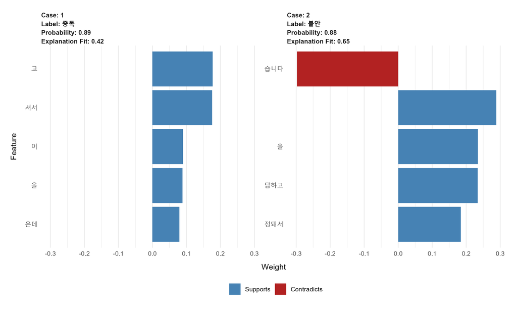

## (3) 실습 2: SBERT 임베딩 기반 SVM 모델에 LIME 적용하기

- 딥러닝 임베딩(SBERT) + SVM 조합에 LIME을 적용하는 것은 BERT 때와 원리는 같지만, 데이터가 흘러가는 경로(파이프라인)가 조금 다름.
  - BERT: 텍스트 $\rightarrow$ [BERT 내부 처리] $\rightarrow$ 확률.
  - SVM + 임베딩: 텍스트 $\rightarrow$ [SBERT로 임베딩 변환] $\rightarrow$ [SVM으로 분류] $\rightarrow$ 확률.
- LIME의 작동원리와 SVM 모델의 특성 사이의 소통불가 문제
  - LIME이 텍스트를 조금씩 바꿀 때마다 매번 다시 임베딩으로 변환해서 SVM에 넣어주는 과정을 우리가 직접 연결해줘야 함.
  - 소요시간이 긴 이유: 문장이 1,000번 바뀔 때마다 SBERT도 임베딩 벡터를 1,000번 바꿔야 하고 SVM도 1,000번 돌아가야 함!
  - 보통 LIME은 모델에게 바로 데이터를 던져줌. 하지만 SVM은 텍스트를 못 읽음. 그래서 우리가 중간에서 “LIME이 텍스트를 줄 때마다, SBERT에게 보내서 숫자로 바꾼 다음, SVM에게 먹여라”라는 작업 지시서를 써줘야 함.
  - 이 작업 지시서를 코드로 짜는 게 바로 “직접 연결하는 과정”임. $\Rightarrow$ 이 작업 지시서를 만드는 과정을 살펴보겠음.
- 가정: 이미 학습된 SVM 모델(`model_svm`)과 SBERT 파이썬 객체(`sbert_model`)가 메모리에 존재함.

### 1) 1단계: SBERT 모델 불러오기

```r
# ------------------------------------------------------------------------------
# 1. SBERT 모델 불러오기
# ------------------------------------------------------------------------------

# 필요한 라이브러리 로드
library(lime)
library(caret)
library(tidyverse)
library(reticulate)

# 1. 파이썬 라이브러리 불러오기
sbert <- import("sentence_transformers")

# 2. 모델 불러오기
# 수업자료의 AutoModel 코드 대신 이걸 써야 함!
model_name <- "jhgan/ko-sbert-nli"
sbert_model <- sbert$SentenceTransformer(model_name)

# 3. 확인(이제 encode 함수가 있는지 테스트)
test_vector <- sbert_model$encode("테스트 문장입니다.")
length(test_vector) # 768이 나오면 성공!
```

### 2) 2단계: 모델과 임베딩 도구를 ’하나의 가방’에 포장하기

- LIME에게 건네줄 ’도시락 가방(wrapper 함수)’을 만듦.

```r
# ------------------------------------------------------------------------------
# 2. 모델(SVM)과 번역기(SBERT)를 하나의 리스트로 묶기
# 설명: SVM은 숫자만 알기 때문에, 텍스트를 숫자로 바꿔줄 SBERT를 꼭 같이 챙겨야 함.
# ------------------------------------------------------------------------------
svm_wrapper <- list(
  model = svm_model, # caret으로 학습시킨 SVM 모델 객체
  embedder = sbert_model # reticulate로 불러온 파이썬 SBERT 객체
)

# [중요] 이 가방에 우리만의 이름표(class)를 붙여줌.
class(svm_wrapper) <- "svm_sbert_model"
```

### 3) 3단계: LIME을 위한 설명서(함수) 작성하기

- 이제 R에게 이 가방(`svm_sbert_model`)이 들어오면 어떻게 예측해야 하는지 알려주는 함수를 정의.

```r
# ------------------------------------------------------------------------------
# 3. 모델 타입 정의(필수)
# 설명: "이 모델은 분류(classification)를 하는 모델입니다"라고 신고하는 과정.
# ------------------------------------------------------------------------------
model_type.svm_sbert_model <- function(x, ...) {
  return("classification")
}

# ------------------------------------------------------------------------------
# 4. 예측함수 정의
# 설명: 텍스트가 들어오면 -> 임베딩으로 바꾸고 -> SVM에 넣어 -> 확률을 뱉어라!
# ------------------------------------------------------------------------------
predict_model.svm_sbert_model <- function(x, newdata, ...) {
  # x: 위에서 만든 svm_wrapper(가방)
  # newdata: LIME이 분석하려고 만든 텍스트들(문자열 벡터)

  # (1) 입력 데이터 문자열로 변환(안전장치)
  texts <- as.character(unlist(newdata))

  # (2) [핵심] 텍스트를 SBERT 임베딩(숫자 벡터)으로 변환
  # - 파이썬 객체인 x$embedder(SBERT)를 사용
  # - 결과는 (문장 수 X 768) 크기의 매트릭스가 됨
  embeddings <- x$embedder$encode(texts)

  # (3) SVM 모델로 예측 수행
  # - caret의 predict 함수 사용
  # - type = "prob"를 써야 '중독일 확률 80%' 같은 확률값이 나옴(SVM 설정에서 classProbs=TRUE 필수)
  probs <- predict(x$model, newdata = embeddings, type = "prob")

  # (4) 결과반환(데이터프레임 형태여야 함)
  return(as.data.frame(probs))
}
```

### 4) 4단계: LIME 설명기 생성 및 실행

- 이제 준비된 가방을 LIME에게 넘겨주고 분석을 시킴.
- 주의사항: SBERT는 무거운 모델이라서, LIME이 문장을 수천 번 조작해서 매번 임베딩을 다시 뽑으면 시간이 꽤 걸릴 수 있음.

```r
# ------------------------------------------------------------------------------
# 5. 설명기(explainer) 생성
# ------------------------------------------------------------------------------
# df_train$text: 텍스트 원본 데이터(임베딩 아님!)
explainer_svm <- lime(
  x = df_train$text[1:5], # 데이터 형식 파악용 샘플
  model = svm_wrapper,# 위에서 만든 가방 투입
  preprocess = function(x) x # 전처리는 SBERT가 알아서 하므로 그대로 패스
)

# ------------------------------------------------------------------------------
# 6. 새로운 문장 분석(explain)
# ------------------------------------------------------------------------------
new_texts <- c("술을 너무 많이 마셔서 일상생활이 안 돼요. 끊고 싶은데 손이 떨려요.",
               "가슴이 답답하고 미래가 너무 걱정돼서 잠을 한숨도 못 잤습니다.")

# explain 실행
# n_permutations: 원래 기본값은 5,000번인데, 속도를 위해 1,000번 정도로 줄임(선택사항)
explanation_svm <- explain(
  x = new_texts,
  explainer = explainer_svm,
  n_labels = 1, # 1등 라벨에 대해서만 설명
  n_features = 5, # 상위 5개 단어만 보여줘
  n_permutations = 1000 # (중요) 속도조절용. 너무 느리면 이 숫자를 줄일 것.
)

# ------------------------------------------------------------------------------
# 7. 시각화
# ------------------------------------------------------------------------------
my_lime_plot_svm <- plot_features(explanation_svm)
my_lime_plot_svm

# 고화질 파일로 저장하기
ggsave(
  filename = "LIME_analysis_result_svm.png",  # 저장할 파일 이름(확장자 포함)
  plot = my_lime_plot_svm,# 위에서 만든 그림 변수
  width = 10, # 가로 길이(인치)
  height = 6,# 세로 길이(인치)
  dpi = 300, # 해상도(논문용은 300 이상 권장)
  units = "in"  # 단위(인치)
  )
```

**[그림 4] SVM 모델 기반 LIME 분석 결과 시각화**

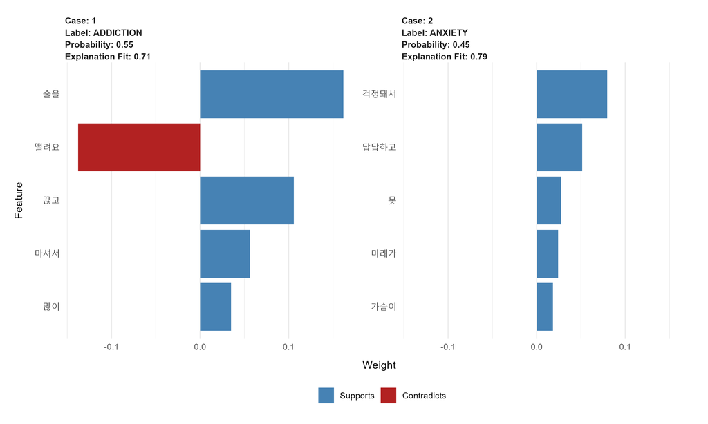

- 비고
  1. 파이프라인의 이해: SVM은 숫자만 먹을 수 있는 편식쟁이. 그래서 LIME이 텍스트를 주면, 중간에 SBERT라는 통역사가 이걸 숫자로 바꿔서 SVM에게 떠먹여줘야 함. `predict_model()` 함수가 바로 그 떠먹여주는 역할을 함.
  2. 속도 차이: BERT 모델보다 이 방식이 조금 더 느릴 수 있음. 왜냐하면 LIME이 문장을 1,000번 변형시키면, SBERT도 1,000번 돌아가야 하기 때문. 시간이 좀 걸려도 멈춘 게 아니니 인내심을 가질 것.
  3. 결과 해석: 결과 그래프 보는 법은 BERT 모델 때와 똑같음. 파란색은 지지, 빨간색은 반박임.

## (4) 결과 그래프 해석 방법

### 1) 일반적 해석 방법

- 제목(label): 그래프 상단에 **중독** 또는 **불안** 이라고 적혀 있음. $\Rightarrow$ 모델이 예측한 결과.
- 막대 색
  - 파란색(supports): 이 단어 때문에 해당 라벨([EX] 중독)일 확률이 높아짐. $\Rightarrow$ 긍정적 증거.
  - 빨간색(contradicts): 이 단어는 해당 라벨이 아닐 가능성을 높임. $\Rightarrow$ 부정적 증거.
- 예시 해석
  - 예시: 첫 번째 문장(“술을 너무 많이…”)에서 **술**, **손이**, **떨려요**가 **파란색 막대**로 길게 나왔다면?
  - 해석: 모델은 이 문장을 ’중독’으로 분류했고, 그 결정적인 근거는 ’술’과 ’손 떨림’이라는 단어였다는 뜻임.

### 2) 예시에 대한 해석

##### 가. LoRA 초매개변수 미세조정 모델

- 예측결과: 모델은 이 텍스트가 ’불안’일 확률을 88%로 예측함.
- 핵심근거(파란색 막대 = 지지)
  - “정돼서”: “걱정돼서”의 뒷부분. ’걱정’이라는 핵심 감정 단어를 잘 포착함.
  - “답하고”: “답답하고”의 뒷부분. 불안의 신체/심리 증상을 나타내는 아주 중요한 단서.
- 반박근거(빨간색 막대 = 반박)
  - “습니다”: 문장 끝의 존댓말 어미. $\Rightarrow$ 이 빨간 막대는 “‘습니다’라는 말투는 ’불안’ 라벨과는 거리가 멀다(오히려 다른 라벨일 가능성을 높인다)”라고 모델이 판단했음을 의미.
  - 이유: 아마도 훈련 데이터(AI 허브 데이터)에서 ’불안’을 호소하는 내담자들은 격식체(“-습니다”)보다는 해요체(“-해요”)나 반말을 더 많이 썼기 때문에 이런 결과가 나왔을 수 있음.
- 해석 및 시사점:
  - 시례 1과 달리, 사례 2는 ‘걱정’, ’답답’이라는 임상적으로 유의미한 핵심 키워드를 근거로 삼았음. 이는 모델이 ’불안’의 맥락을 아주 잘 학습했음을 보여주는 긍정적인 신호임.

##### 나. SVM 모델

- 예측결과: 모델은 이 텍스트가 ’불안’일 확률을 45%로 예측함. 이는 예측에 실패했거나(확률 $<$ 50%), 다른 라벨과 경합 중임을 의미함. 매우 낮은 확신도임.
- 핵심근거(파란색 막대 = 지지):
  - “걱정돼서”: 불안의 핵심 정서인 ’걱정’을 가장 중요한 근거로 포착함.
  - “미래가”: 불안의 인지적 특성(미래에 대한 부정적 예기)을 나타내는 단어를 잘 잡아냄.
  - “답답하고”, “못”: 신체증상과 부정 부사도 불안 예측에 기여함.
- 반박근거(빨간색 막대 = 반박): 적어도 상위 5개 단어에는 없음.
- 해석 및 시사점
  - 모델은 ‘걱정’, ‘미래’, ‘답답’ 등 불안장애의 진단기준에 부합하는 단어들을 정확히 찾아냈음. 질적으로는 매우 우수한 판단근거를 가지고 있음.
  - 그러나 낮은 확률(45%)은 SBERT 임베딩 공간 내에서 ‘불안’과 ’우울’ 데이터가 서로 매우 가깝게 뭉쳐 있어, SVM이 명확한 경계선을 긋지 못하고 있음을 보여줌. 즉 방향은 맞았으나 확신이 부족한 상태임.

#### C. BERT의 두 얼굴

- 두 그림 간 비교
  - 오른쪽(불안) 그림: 아주 모범적. ‘걱정’, ‘답답’ 같은 단어를 보고 불안이라고 판단했으니, 심리상담사처럼 제대로 진단한 셈.
  - 왼쪽(중독) 그림: ‘술’이라는 단어 대신 ’셔서’, ‘은데’ 같은 말투(style)를 보고 중독이라고 판단. 이건 마치 환자의 말 내용(content)은 안 듣고, 말하는 억양만 보고 진단하는 것과 비슷.
- LIME을 돌려보면 모델이 정말 똑똑하게 판단했는지, 아니면 이상한 단어를 보고 찍었는지 알 수 있음.
- 예시
  - 우울증 글인데 ’ㅋㅋㅋ’가 많다고 ’일반’으로 분류했다면, 그 모델은 잘못 학습된 것.
  - LIME은 이렇게 모델의 편향을 잡아내고, 임상적으로 타당한 근거를 사용하는지 검증하는 데 필수적인 도구임.

#### D. 종합비교: 딥러닝(fine-tuned BERT) vs. SVM(SBERT embedding)

- BERT(미세조정): 확신도가 매우 높음(80~90%). 그러나 판단근거가 조사/어미 등 **말투**에 편향되는 경향이 있음. $\Rightarrow$ 과적합 위험.
- SVM(SBERT): 확신도가 낮음(40~60%). 그러나 판단근거가 ‘술’, ‘미래’, ‘걱정’ 등 **핵심의미**에 집중되어 있어 임상적 타당성은 오히려 더 높아 보임. $\Rightarrow$ 일반화 가능성 높음.

# 11. 전체 요약

- **임베딩의 진화:** 단어를 숫자로 바꾸는 기법이 정적 임베딩(word2vec)에서 문맥을 고려하는 동적 임베딩(트랜스포머)으로 발전했음.
- **Hugging Face 생태계:** 전 세계의 사전학습 모델을 R 환경에서도 **reticulate** 패키지를 통해 쉽게 활용할 수 있음.
- **임베딩의 활용:** 추출된 문장 임베딩은 분류, 군집화, 시각화 등 다양한 심리학적 텍스트 분석에서 강력한 도구가 됨.
- **효율적인 미세조정(LoRA):** 거대한 최신 모델도 LoRA와 같은 PEFT 기법을 사용하면 일반적인 연구환경에서 충분히 나만의 데이터로 맞춤 학습시킬 수 있음.
- **LIME의 효용성:** LIME은 이렇게 모델이 제대로 알고 맞힌 건지, 소 뒷걸음질 치다 맞힌 건지 감시할 수 있게 해주는 아주 중요한 도구임. 우리가 앞으로 데이터를 더 많이 모아서 학습시켜야 하는 이유가 바로 여기에 있음.